# Tipología y Ciclo de Vida de los datos.PRA2

# Tipologia y Ciclo de vida de los Datos. Practica 2

Autores: Alexis Germán Arroyo Peña y Gabriel Pulido de Torres

Enero 2021

# 1 Descripción del dataset. ¿Por qué es importante y qué pregunta/problema pretende responder?

Como objetivo de esta práctica se ha optado por analizar el conjunto de datos del titanic.

Este conjunto de datos incluye información acerca de los pasajeros que iban en el Titanic, en el que murieron 1500 personas en 1912. Disponemos tanto de información descriptiva del tipo de pasajero como un indicador de su supervivencia al hundimiento o no. La pregunta que nos marcamos como objetivo es: ¿las variables aportadas son suficientes para crear un modelo predictivo que prediga la supervivencia de un determinado pasajero?

El conjunto de datos del Titanic permite entrenar modelos predictivos supervisados. Contiene un número manejable de datos y de atributos de distintos tipos. Además, es un conjunto que no está limpio (por ejemplo, contiene elementos nulos) lo que obligará a poner en práctica técnicas aprendidas de limpieza de datos.

**Estructura del dataset**

A continuación, realizamos un primer contacto con el conjunto de datos, visualizando su estructura.

```r
# Cargamos el fichero de datos
data <- read.csv('../data/train.csv',stringsAsFactors = FALSE, na.strings = "")
dim.data.frame(data)
```

```
## [1] 891  12
```

```r
# Verificamos la estructura del conjunto de datos
str(data)
```

```
## 'data.frame':    891 obs. of  12 variables:
##  $ PassengerId: int  1 2 3 4 5 6 7 8 9 10 ...
##  $ Survived   : int  0 1 1 1 0 0 0 0 1 1 ...
##  $ Pclass     : int  3 1 3 1 3 3 1 3 3 2 ...
##  $ Name       : chr  "Braund, Mr. Owen Harris" "Cumings, Mrs. John Bradley (Florence Briggs Thayer)" "Heikkinen, Miss. Laina" "Futrelle, Mrs. Jacques Heath (Lily May Peel)" ...
##  $ Sex        : chr  "male" "female" "female" "female" ...
##  $ Age        : num  22 38 26 35 35 NA 54 2 27 14 ...
##  $ SibSp      : int  1 1 0 1 0 0 0 3 0 1 ...
##  $ Parch      : int  0 0 0 0 0 0 0 1 2 0 ...
##  $ Ticket     : chr  "A/5 21171" "PC 17599" "STON/O2. 3101282" "113803" ...
##  $ Fare       : num  7.25 71.28 7.92 53.1 8.05 ...
##  $ Cabin      : chr  NA "C85" NA "C123" ...
##  $ Embarked   : chr  "S" "C" "S" "S" ...
```

El conjunto de datos está formado 12 variables y 891 observaciones.

**Descripción del conjunto de datos:**

- Passengerld: Contador de pasajeros del 1 al 891.
- Survived: nos indica si el pasajero sobrevivió o no (0= No, 1= Si).
- pClass: nos indica la clase a la que pertenece el ticket, 1=1st (clase alta), 2=2nd (clase media) y 3=3rd (clase baja).
- Name: nombre completo del pasajero.
- Sex: sexo del pasajero (Female o Male).
- Age: edad del pasajero
- SibSp: número de hermanos/hermanas, hermanastros/hermanastros y marido o esposa del pasajero que también iban a bordo.
- Parch: número de hijas, hijos, padre y madre del pasajero a bordo del Titanic.
- Ticket: número del ticket del pasajero.
- Fare: la tarifa del pasajero en dólares.
- Cabin: código identificativo de la cabina.
- Embarked: el puerto en el que embarcó el pasajero (C = Cherbourg, Q =Queenstown, S = Southampton).

# 2 Integración y selección de los datos de interés a analizar.

El conjunto de datos que se proporciona en Kaggle está dividido en dos partes, un conjunto de datos de train, y un conjunto de datos de test. La diferencia principal es que mientras que en el conjunto de datos de train disponemos del valor de la variable Survived, en el de test no disponemos de esa variable.

Como parte de los modelos que vamos a diseñar son modelos supervisados, a la hora de validarlos no podemos usar el conjunto de datos de test, por lo que hemos optado trabajar únicamente con los de train sin fusionarlos.

En el apartado anterior leímos los datos en un dataframe (al que llamamos “data”). Recordamos su dimensionalidad y comprobamos los nombres y tipos de las variables.

```
## [1] 891  12
```

```
## PassengerId    Survived      Pclass        Name         Sex         Age
##   "integer"   "integer"   "integer" "character" "character"   "numeric"
##       SibSp       Parch      Ticket        Fare       Cabin    Embarked
##   "integer"   "integer" "character"   "numeric" "character" "character"
```

Comprobamos si hay registros duplicados usando el comando unique()

```r
data_unique <- unique(data)
dim.data.frame(data_unique)
```

```
## [1] 891  12
```

```r
remove(data_unique)
```

La dimensionalidad ha quedado exactamente igual que cuando cargamos el conjunto de datos. Esto nos hace ver que no existen registros duplicados.

Revisamos la estructura de nuestro dataset:

```r
summary(data)
```

```
##   PassengerId       Survived          Pclass          Name
##  Min.   :  1.0   Min.   :0.0000   Min.   :1.000   Length:891
##  1st Qu.:223.5   1st Qu.:0.0000   1st Qu.:2.000   Class :character
##  Median :446.0   Median :0.0000   Median :3.000   Mode  :character
##  Mean   :446.0   Mean   :0.3838   Mean   :2.309
##  3rd Qu.:668.5   3rd Qu.:1.0000   3rd Qu.:3.000
##  Max.   :891.0   Max.   :1.0000   Max.   :3.000
##
##      Sex                 Age            SibSp           Parch
##  Length:891         Min.   : 0.42   Min.   :0.000   Min.   :0.0000
##  Class :character   1st Qu.:20.12   1st Qu.:0.000   1st Qu.:0.0000
##  Mode  :character   Median :28.00   Median :0.000   Median :0.0000
##                     Mean   :29.70   Mean   :0.523   Mean   :0.3816
##                     3rd Qu.:38.00   3rd Qu.:1.000   3rd Qu.:0.0000
##                     Max.   :80.00   Max.   :8.000   Max.   :6.0000
##                     NA's   :177
##     Ticket               Fare           Cabin             Embarked
##  Length:891         Min.   :  0.00   Length:891         Length:891
##  Class :character   1st Qu.:  7.91   Class :character   Class :character
##  Mode  :character   Median : 14.45   Mode  :character   Mode  :character
##                     Mean   : 32.20
##                     3rd Qu.: 31.00
##                     Max.   :512.33
##
```

```r
df_status(data)
```

```
##       variable q_zeros p_zeros q_na  p_na q_inf p_inf      type unique
## 1  PassengerId       0    0.00    0  0.00     0     0   integer    891
## 2     Survived     549   61.62    0  0.00     0     0   integer      2
## 3       Pclass       0    0.00    0  0.00     0     0   integer      3
## 4         Name       0    0.00    0  0.00     0     0 character    891
## 5          Sex       0    0.00    0  0.00     0     0 character      2
## 6          Age       0    0.00  177 19.87     0     0   numeric     88
## 7        SibSp     608   68.24    0  0.00     0     0   integer      7
## 8        Parch     678   76.09    0  0.00     0     0   integer      7
## 9       Ticket       0    0.00    0  0.00     0     0 character    681
## 10        Fare      15    1.68    0  0.00     0     0   numeric    248
## 11       Cabin       0    0.00  687 77.10     0     0 character    147
## 12    Embarked       0    0.00    2  0.22     0     0 character      3
```

Podemos visualizar una muestra de los primeros registros de nuestro dataframe:

```r
kbl(head(data, n = 10), booktabs = T) %>%
  kable_styling(latex_options = c("striped", "scale_down"))
```

| PassengerId | Survived | Pclass | Name | Sex | Age | SibSp | Parch | Ticket | Fare | Cabin | Embarked |
| --- | --- | --- | --- | --- | --- | --- | --- | --- | --- | --- | --- |
| 1 | 0 | 3 | Braund, Mr. Owen Harris | male | 22 | 1 | 0 | A/5 21171 | 7.2500 | NA | S |
| 2 | 1 | 1 | Cumings, Mrs. John Bradley (Florence Briggs Thayer) | female | 38 | 1 | 0 | PC 17599 | 71.2833 | C85 | C |
| 3 | 1 | 3 | Heikkinen, Miss. Laina | female | 26 | 0 | 0 | STON/O2. 3101282 | 7.9250 | NA | S |
| 4 | 1 | 1 | Futrelle, Mrs. Jacques Heath (Lily May Peel) | female | 35 | 1 | 0 | 113803 | 53.1000 | C123 | S |
| 5 | 0 | 3 | Allen, Mr. William Henry | male | 35 | 0 | 0 | 373450 | 8.0500 | NA | S |
| 6 | 0 | 3 | Moran, Mr. James | male | NA | 0 | 0 | 330877 | 8.4583 | NA | Q |
| 7 | 0 | 1 | McCarthy, Mr. Timothy J | male | 54 | 0 | 0 | 17463 | 51.8625 | E46 | S |
| 8 | 0 | 3 | Palsson, Master. Gosta Leonard | male | 2 | 3 | 1 | 349909 | 21.0750 | NA | S |
| 9 | 1 | 3 | Johnson, Mrs. Oscar W (Elisabeth Vilhelmina Berg) | female | 27 | 0 | 2 | 347742 | 11.1333 | NA | S |
| 10 | 1 | 2 | Nasser, Mrs. Nicholas (Adele Achem) | female | 14 | 1 | 0 | 237736 | 30.0708 | NA | C |

Existen variables que carecen de interés por ser identificadoras de cada registro. Estamos haciendo referencia a “PassengerId”, “Ticket” y “Name”. No nos interesa tener unívocamente identificado cada caso para realizar algún tipo de análisis por lo que no aportan nada a nuestro estudio.

## 2.1 PersonasTicket y Price

Antes de eliminar la variable **Ticket**, nos va a servir para conocer el precio unitario que han pagado los pasajeros, ya que la variable **Fare** es la tarifa pagada en el ticket, pero dentro del mismo ticket pueden incluirse a varias personas. Inicialmente, vamos a obtener el número de personas que están incluidas en un mismo ticket.

```r
nrow(table(data$Ticket, data$Fare))
```

```
## [1] 681
```

```r
length(unique(data$Ticket))
```

```
## [1] 681
```

```r
dt <- data %>% group_by(Ticket, Fare) %>%
  filter(row_number() == 1)

kbl(head(dt, n = 20), booktabs = T) %>%
  kable_styling(latex_options = c("striped", "scale_down"))
```

| PassengerId | Survived | Pclass | Name | Sex | Age | SibSp | Parch | Ticket | Fare | Cabin | Embarked |
| --- | --- | --- | --- | --- | --- | --- | --- | --- | --- | --- | --- |
| 1 | 0 | 3 | Braund, Mr. Owen Harris | male | 22 | 1 | 0 | A/5 21171 | 7.2500 | NA | S |
| 2 | 1 | 1 | Cumings, Mrs. John Bradley (Florence Briggs Thayer) | female | 38 | 1 | 0 | PC 17599 | 71.2833 | C85 | C |
| 3 | 1 | 3 | Heikkinen, Miss. Laina | female | 26 | 0 | 0 | STON/O2. 3101282 | 7.9250 | NA | S |
| 4 | 1 | 1 | Futrelle, Mrs. Jacques Heath (Lily May Peel) | female | 35 | 1 | 0 | 113803 | 53.1000 | C123 | S |
| 5 | 0 | 3 | Allen, Mr. William Henry | male | 35 | 0 | 0 | 373450 | 8.0500 | NA | S |
| 6 | 0 | 3 | Moran, Mr. James | male | NA | 0 | 0 | 330877 | 8.4583 | NA | Q |
| 7 | 0 | 1 | McCarthy, Mr. Timothy J | male | 54 | 0 | 0 | 17463 | 51.8625 | E46 | S |
| 8 | 0 | 3 | Palsson, Master. Gosta Leonard | male | 2 | 3 | 1 | 349909 | 21.0750 | NA | S |
| 9 | 1 | 3 | Johnson, Mrs. Oscar W (Elisabeth Vilhelmina Berg) | female | 27 | 0 | 2 | 347742 | 11.1333 | NA | S |
| 10 | 1 | 2 | Nasser, Mrs. Nicholas (Adele Achem) | female | 14 | 1 | 0 | 237736 | 30.0708 | NA | C |
| 11 | 1 | 3 | Sandstrom, Miss. Marguerite Rut | female | 4 | 1 | 1 | PP 9549 | 16.7000 | G6 | S |
| 12 | 1 | 1 | Bonnell, Miss. Elizabeth | female | 58 | 0 | 0 | 113783 | 26.5500 | C103 | S |
| 13 | 0 | 3 | Saundercock, Mr. William Henry | male | 20 | 0 | 0 | A/5. 2151 | 8.0500 | NA | S |
| 14 | 0 | 3 | Andersson, Mr. Anders Johan | male | 39 | 1 | 5 | 347082 | 31.2750 | NA | S |
| 15 | 0 | 3 | Vestrom, Miss. Hulda Amanda Adolfina | female | 14 | 0 | 0 | 350406 | 7.8542 | NA | S |
| 16 | 1 | 2 | Hewlett, Mrs. (Mary D Kingcome) | female | 55 | 0 | 0 | 248706 | 16.0000 | NA | S |
| 17 | 0 | 3 | Rice, Master. Eugene | male | 2 | 4 | 1 | 382652 | 29.1250 | NA | Q |
| 18 | 1 | 2 | Williams, Mr. Charles Eugene | male | NA | 0 | 0 | 244373 | 13.0000 | NA | S |
| 19 | 0 | 3 | Vander Planke, Mrs. Julius (Emelia Maria Vandemoortele) | female | 31 | 1 | 0 | 345763 | 18.0000 | NA | S |
| 20 | 1 | 3 | Masselmani, Mrs. Fatima | female | NA | 0 | 0 | 2649 | 7.2250 | NA | C |

Podemos obtener el precio por persona al dividir Fare entre los integrantes del ticket:

```r
ticket_personas <- as.data.frame(data %>%
                                   group_by(Ticket) %>%
                                   dplyr::summarize(PersonasTicket=n()))
```

Creamos un nuevo dataframe, “ticket_personas” al que asignamos las variables **Ticket** y **PersonasTicket**

```r
df_status(ticket_personas)
```

```
##         variable q_zeros p_zeros q_na p_na q_inf p_inf      type unique
## 1         Ticket       0       0    0    0     0     0 character    681
## 2 PersonasTicket       0       0    0    0     0     0   integer      7
```

Este dataframe lo combinamos con el dataframe original a través del número de ticket para incorporar el número de personas al dataframe original. Tras lo cual podemos eliminar el dataframe ticket_personas.

```r
data <- merge(data, ticket_personas, by = "Ticket")
remove(ticket_personas)
```

Hemos incluido a nuestros datos la variable nueva “PersonasTicket”, la cual utilizaremos para dividir la tarifa del ticket “Fare” entre “PersonasTicket” para crear la variable “Price”. Esta nueva variable representa el precio por persona que se paga en el billete.

```r
data$Price <- data$Fare / data$PersonasTicket
```

Tras realizar esto, procedemos a eliminar todas las variables que no utilizaremos: PassengerId, Name, Ticket, PersonasTicket:

```r
data <- select(data, -PassengerId, -Name, -Ticket, -PersonasTicket)
```

## 2.2 FamilySize

Podemos crear una nueva variable, **FamilySize**, que será la suma de **Parch** (número de padres / hijos a bordo) y **SibSp** (sibling: número de hermanos del pasajero, spouse: cónyuge del pasajero), más el propio viajero en cuestión (haciendo esta variable como mínimo igual a 1).

```r
data$FamilySize = data$Parch + data$SibSp + 1
```

## 2.3 Revisión y conversion de tipos

Debemos convertir las variables **Sex**, **Survived**, **Pclass** y **Embarked** a “factor”. Estas tienen un número finito de valores por lo que, aunque puedan ser numéricas, las discretizamos convirtiendo sus valores en factores.

```r
data$Sex <- as.factor(data$Sex)
data$Survived <- as.factor(data$Survived)
data$Pclass <- as.factor(data$Pclass)
data$Embarked <- as.factor(data$Embarked)
```

Nos quedarían como variables numéricas: **Age**, **SubSp**, **Parch**, **FamilySize**, **Fare** y **Price**

```r
summary(data)
```

```
##  Survived Pclass      Sex           Age            SibSp           Parch
##  0:549    1:216   female:314   Min.   : 0.42   Min.   :0.000   Min.   :0.0000
##  1:342    2:184   male  :577   1st Qu.:20.12   1st Qu.:0.000   1st Qu.:0.0000
##           3:491                Median :28.00   Median :0.000   Median :0.0000
##                                Mean   :29.70   Mean   :0.523   Mean   :0.3816
##                                3rd Qu.:38.00   3rd Qu.:1.000   3rd Qu.:0.0000
##                                Max.   :80.00   Max.   :8.000   Max.   :6.0000
##                                NA's   :177
##       Fare           Cabin           Embarked       Price
##  Min.   :  0.00   Length:891         C   :168   Min.   :  0.000
##  1st Qu.:  7.91   Class :character   Q   : 77   1st Qu.:  7.763
##  Median : 14.45   Mode  :character   S   :644   Median :  8.850
##  Mean   : 32.20                      NA's:  2   Mean   : 17.789
##  3rd Qu.: 31.00                                 3rd Qu.: 24.288
##  Max.   :512.33                                 Max.   :221.779
##
##    FamilySize
##  Min.   : 1.000
##  1st Qu.: 1.000
##  Median : 1.000
##  Mean   : 1.905
##  3rd Qu.: 2.000
##  Max.   :11.000
##
```

# 3 Limpieza de los datos.

```r
df_status(data)
```

```
##      variable q_zeros p_zeros q_na  p_na q_inf p_inf      type unique
## 1    Survived     549   61.62    0  0.00     0     0    factor      2
## 2      Pclass       0    0.00    0  0.00     0     0    factor      3
## 3         Sex       0    0.00    0  0.00     0     0    factor      2
## 4         Age       0    0.00  177 19.87     0     0   numeric     88
## 5       SibSp     608   68.24    0  0.00     0     0   integer      7
## 6       Parch     678   76.09    0  0.00     0     0   integer      7
## 7        Fare      15    1.68    0  0.00     0     0   numeric    248
## 8       Cabin       0    0.00  687 77.10     0     0 character    147
## 9    Embarked       0    0.00    2  0.22     0     0    factor      3
## 10      Price      15    1.68    0  0.00     0     0   numeric    248
## 11 FamilySize       0    0.00    0  0.00     0     0   numeric      9
```

## 3.1 Elementos nulos y ceros.

### 3.1.1 Corrección de elementos nulos

Vamos a analizar los elementos nulos que se encuentran en el dataset

En la tabla anterior observamos que el campo **Age** tiene un 19.87% de nulos, **Cabin** más de un 77% y **Embarked** tiene 2 valores nulos. Analizamos cada uno de ellos con más detalles para decidir las acciones a realizar.

#### 3.1.1.1 Cabin

Por su número tan elevado de casos, un 77%, y por no ser significativa para nuestros objetivos, se opta por eliminar esta variable.

```r
data <- select(data, -Cabin)
```

#### 3.1.1.2 Embarked

Esta variable presenta 2 valores nulos. Al ser pocos casos, decidimos imputar el valor que más se repite: Embarked=S (Southampton)

```r
data %>% group_by(Embarked) %>% count(Embarked)
```

```
## # A tibble: 4 x 2
## # Groups:   Embarked [4]
##   Embarked     n
##   <fct>    <int>
## 1 C          168
## 2 Q           77
## 3 S          644
## 4 <NA>         2
```

```r
data_Embarked <- sort(table(data$Embarked, useNA = "ifany"), decreasing = TRUE)
```

Gráficamente:

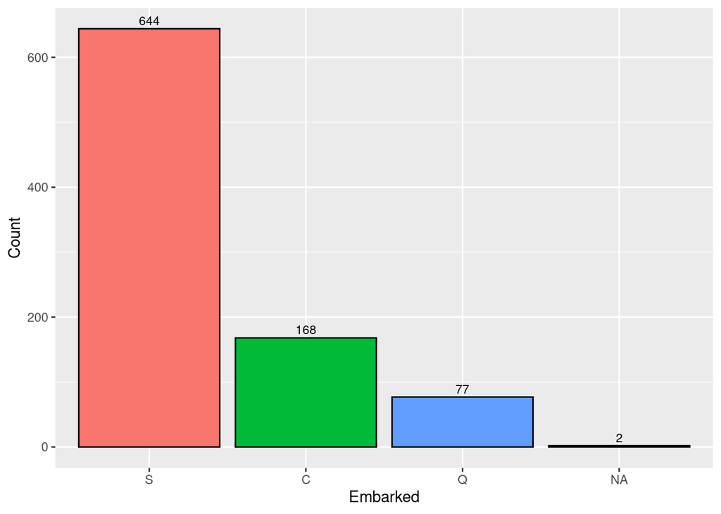

```r
dat_plot <- as.data.frame(data_Embarked)
ggplot(dat_plot, aes(x=Var1, y=Freq, fill=Var1)) +
  geom_bar(stat = "identity", color = "black") +
  geom_text(aes(label=Freq), vjust = -0.4, color="black", size=3) +
  labs(x='Embarked', y='Count') +
  theme(legend.position = "none")
```

```r
data$Embarked[is.na(data$Embarked)] <- names(data_Embarked[1])
```

#### 3.1.1.3 Age

Contiene concretamente 177 registros con valores nulos.

Analizamos la distribución de la variable **Age** teniendo en cuenta sólo los registros donde hay valores. Para ello creamos un nuevo dataset sin los registros nulos de Age:

```r
data_NoNA <- data[which(!is.na(data$Age)),]
```

Observamos gráficamente como se distribuye la variable Age en este dataset:

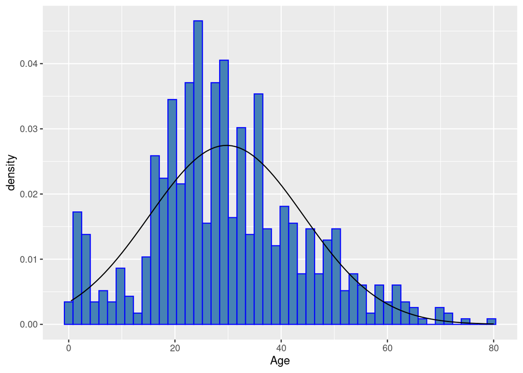

Comprobamos posibles relaciones entre la edad y alguna otra variable. Para ello iremos analizando Age con las distintas variables.

##### 3.1.1.3.1 Age vs Sex

Observamos gráficamente la relación entre la edad y el género

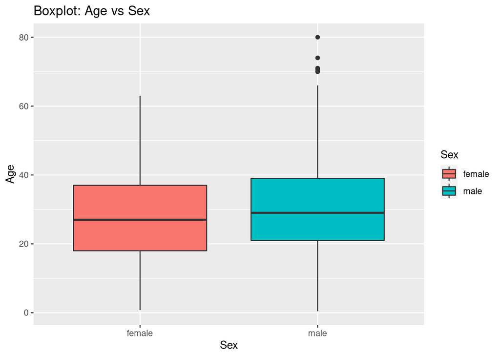

No se aprecian diferencias significativas de edad en función del género

##### 3.1.1.3.2 Age vs Embarked

Observamos gráficamente la relación entre la edad y el puerto de Embarque

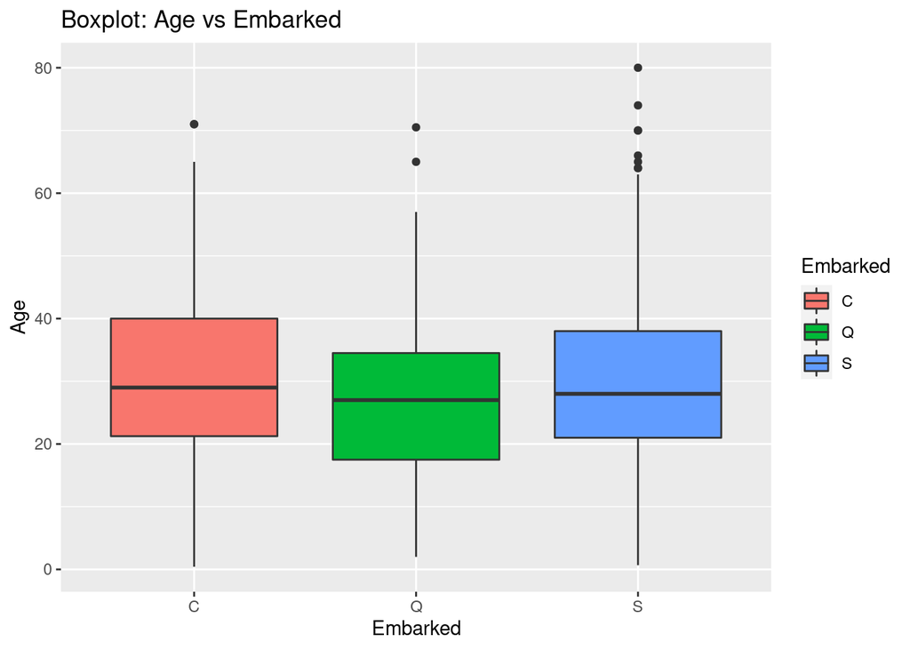

No se aprecian diferencias significativas con respecto a las medias de edad en cada una de las clases de **Embarked**.

##### 3.1.1.3.3 Age vs Pclass

Observamos gráficamente la relación entre Age y Pclass:

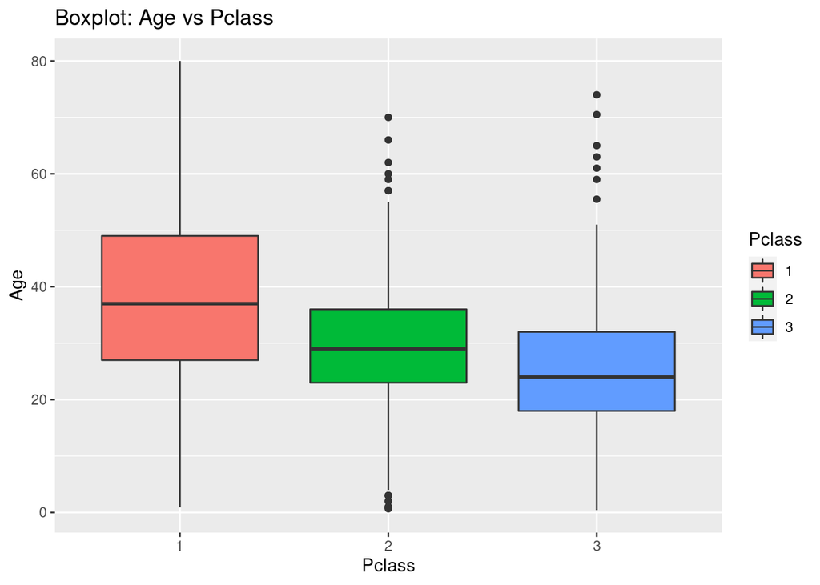

Observamos una relación entre la edad y la clase en que viajaban los pasajeros: Los pasajeros de clase 1 (alta) tenían generalmente mayor edad que los de clase 2 (media) e igualmente sucede con los de clase 3 (baja). Lo cual es lógico (más edad más poder adquisitivo).

##### 3.1.1.3.4 Age vs Variables numéricas

Vemos las distintas correlaciones de las variables numéricas

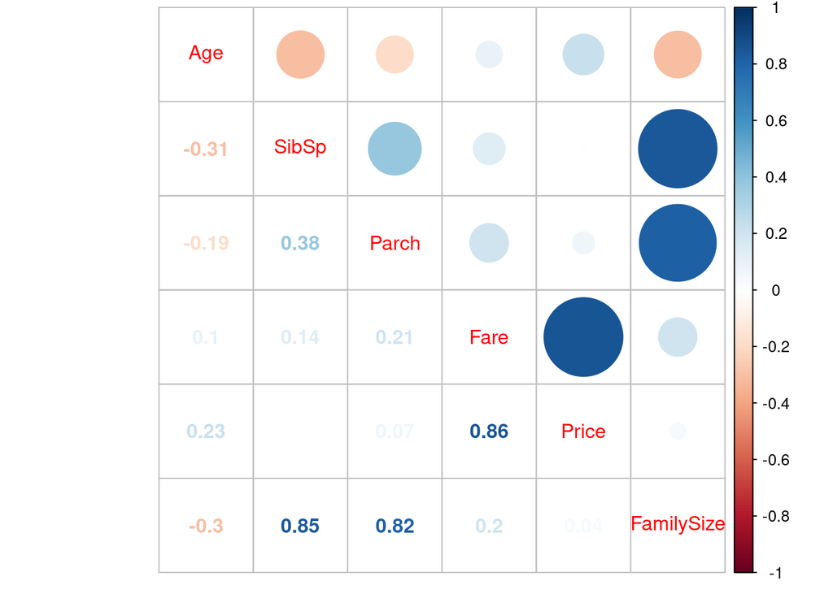

Observamos una correlación negativa con **SibSp** y con **Parch**.

##### 3.1.1.3.5 Imputación de valores a Age

Vamos a realizar dos simulaciones diferentes de imputación y nos quedaremos con la mejor:

**Caso 1: Imputar la media de Age a todos los elementos faltantes**

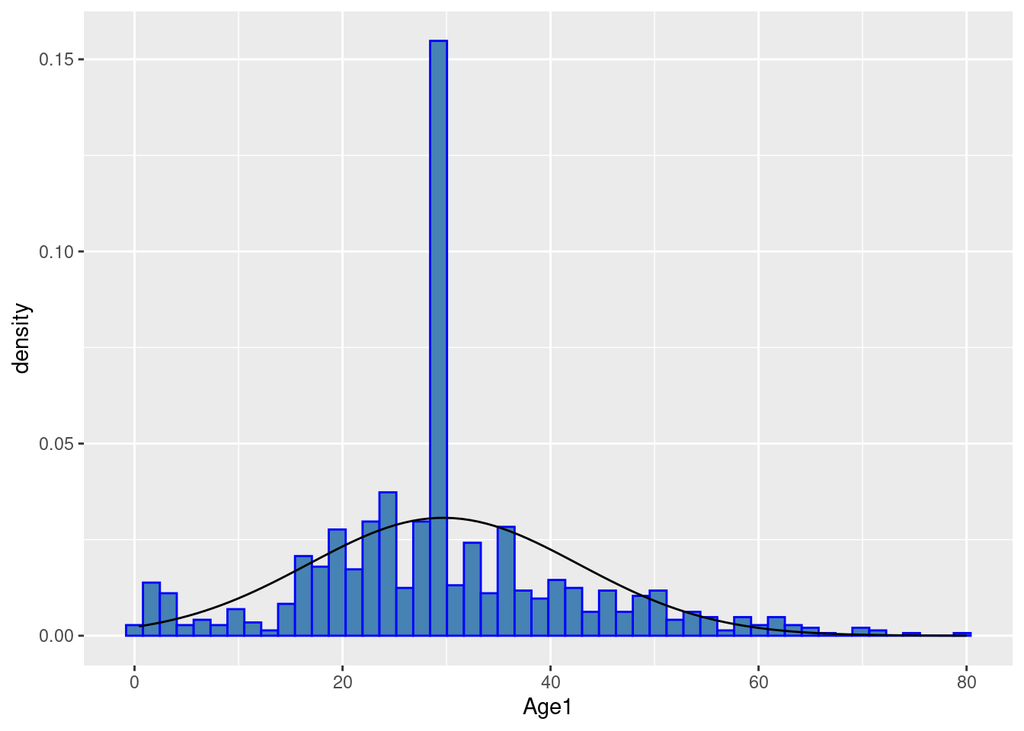

```r
data$Age1 <- data$Age
data$Age1[is.na(data$Age1)] <- mean(data_NoNA$Age)

ggplot(data, aes(Age1)) +
  geom_histogram(aes(y = ..density..), bins=50, fill="steelblue", color="blue") +
  stat_function(fun = dnorm, args = list(mean = mean(data$Age1), sd = sd(data$Age1)))
```

**Caso 2: Imputando datos de** Age**, con MICE (Multivariate Imputation via Chained Equations)**

En este caso se predicen los valores de **Age**, con el resto de valores observados (**Pclass**, **SibSp**, **Parch**, **Sex** y **Age**).

```r
columnas <- c('Pclass', 'SibSp', 'Parch', 'Sex', 'Age')

mice_imputar <- mice(data = data[, columnas], method = "rf")
mice_completo <- mice::complete(mice_imputar)
data$Age2 <- data$Age
data$Age2[is.na(data$Age2)]<- mice_completo$Age[is.na(data$Age2)]
```

Observamos la gráfica:

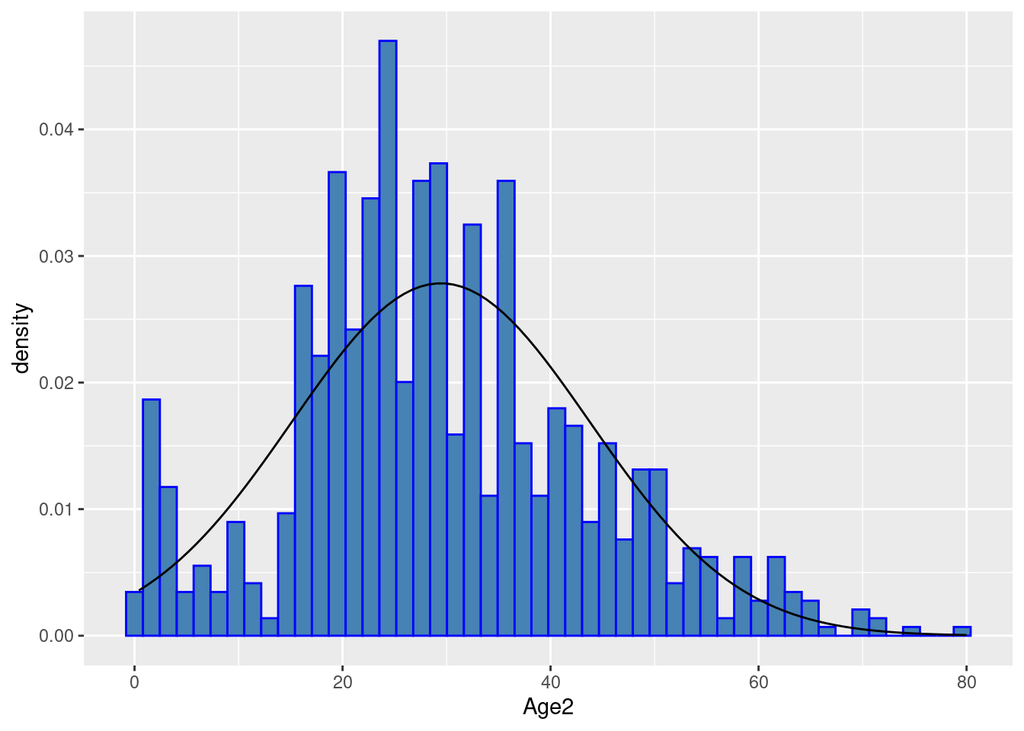

Mostramos el resultado de las opciones de imputación más la original:

```r
summary(data$Age)
```

```
##    Min. 1st Qu.  Median    Mean 3rd Qu.    Max.    NA's
##    0.42   20.12   28.00   29.70   38.00   80.00     177
```

```r
summary(data$Age1)
```

```
##    Min. 1st Qu.  Median    Mean 3rd Qu.    Max.
##    0.42   22.00   29.70   29.70   35.00   80.00
```

```r
summary(data$Age2)
```

```
##    Min. 1st Qu.  Median    Mean 3rd Qu.    Max.
##    0.42   20.00   28.00   29.45   38.00   80.00
```

Tras ver los resultados nos decantamos por la segunda opción (Age2), ya que la distribución se parece mucho más a la original. Asignamos y limpiamos el conjunto de datos:

```r
data$Age <- data$Age2
data <- select(data, -Age1, -Age2)
```

### 3.1.2 Valores igual a cero

Recordamos los valores con ceros del dataset

```
##      variable q_zeros p_zeros q_na p_na q_inf p_inf    type unique
## 1    Survived     549   61.62    0    0     0     0  factor      2
## 2      Pclass       0    0.00    0    0     0     0  factor      3
## 3         Sex       0    0.00    0    0     0     0  factor      2
## 4         Age       0    0.00    0    0     0     0 numeric     88
## 5       SibSp     608   68.24    0    0     0     0 integer      7
## 6       Parch     678   76.09    0    0     0     0 integer      7
## 7        Fare      15    1.68    0    0     0     0 numeric    248
## 8    Embarked       0    0.00    0    0     0     0  factor      3
## 9       Price      15    1.68    0    0     0     0 numeric    248
## 10 FamilySize       0    0.00    0    0     0     0 numeric      9
```

Tenemos un alto número de valores cero tanto en **SibSp** como en **Parch**. No obstante, son valores válidos dentro del rango para estas variables ya que expresan el número de acompañantes del pasajero. Sorprende que hay algunos valores cero en **Fare**, aunque pudiera significar que esos tickets fueron gratis debido a algún sorteo o regalo.

### 3.1.3 Conclusión limpieza nulos y ceros

```r
summary(data)
```

```
##  Survived Pclass      Sex           Age            SibSp           Parch
##  0:549    1:216   female:314   Min.   : 0.42   Min.   :0.000   Min.   :0.0000
##  1:342    2:184   male  :577   1st Qu.:20.00   1st Qu.:0.000   1st Qu.:0.0000
##           3:491                Median :28.00   Median :0.000   Median :0.0000
##                                Mean   :29.45   Mean   :0.523   Mean   :0.3816
##                                3rd Qu.:38.00   3rd Qu.:1.000   3rd Qu.:0.0000
##                                Max.   :80.00   Max.   :8.000   Max.   :6.0000
##       Fare        Embarked     Price           FamilySize
##  Min.   :  0.00   C:168    Min.   :  0.000   Min.   : 1.000
##  1st Qu.:  7.91   Q: 77    1st Qu.:  7.763   1st Qu.: 1.000
##  Median : 14.45   S:646    Median :  8.850   Median : 1.000
##  Mean   : 32.20            Mean   : 17.789   Mean   : 1.905
##  3rd Qu.: 31.00            3rd Qu.: 24.288   3rd Qu.: 2.000
##  Max.   :512.33            Max.   :221.779   Max.   :11.000
```

Observamos también los datos tras eliminar variables y tras imputar valores en aquellas variables que presentaban valores nulos.

```r
df_status(data)
```

```
##      variable q_zeros p_zeros q_na p_na q_inf p_inf    type unique
## 1    Survived     549   61.62    0    0     0     0  factor      2
## 2      Pclass       0    0.00    0    0     0     0  factor      3
## 3         Sex       0    0.00    0    0     0     0  factor      2
## 4         Age       0    0.00    0    0     0     0 numeric     88
## 5       SibSp     608   68.24    0    0     0     0 integer      7
## 6       Parch     678   76.09    0    0     0     0 integer      7
## 7        Fare      15    1.68    0    0     0     0 numeric    248
## 8    Embarked       0    0.00    0    0     0     0  factor      3
## 9       Price      15    1.68    0    0     0     0 numeric    248
## 10 FamilySize       0    0.00    0    0     0     0 numeric      9
```

## 3.2 Identificación y tratamiento de valores extremos.

Se considera un valor extremo, outlier, a un valor fuera de rango. Son valores que se salen de la escala esperada visualizando el resto de las observaciones. En la actualidad, el criterio más habitual es considerar un valor extremo a aquel que se encuentra alejado de la media unas tres veces la desviación típica.

**Gráfico boxplot variables numéricas**

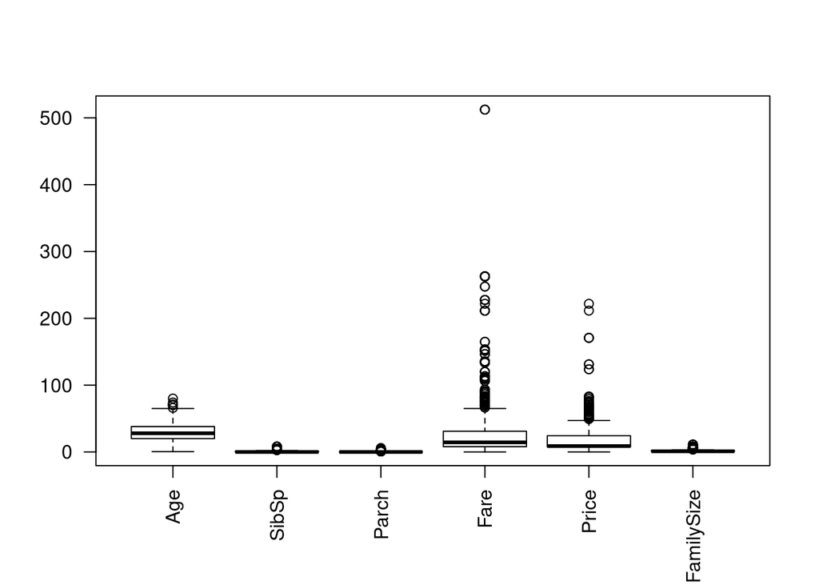

```r
lista<-sapply(data, is.numeric)
data_num<-data[,lista]
boxplot(data_num,las=2)
```

```r
var.continuas <- vector()
```

De todas las variables numéricas sólamente tres son contínuas: **Age**, **Price** y **Fare**

Analicemos esas tres variables por separado

### 3.2.1 Fare

El boxplot parece indicar que Fare tiene valores extremos. Los identificamos usando el criterio de tres veces la desviación típica:

```r
data_out <- as.data.frame(data$Fare)
data_out$outlier <- FALSE
for (i in 1:ncol(data_out) - 1){
  columna = data_out[, i]
  if (is.numeric(columna)) {
    media = mean(columna)
    desviacion = sd(columna)
    data_out$outlier = (columna> (media+3*desviacion) | columna<(media-3*desviacion))
  }
}
table(data_out$outlier)
```

```
##
## FALSE  TRUE
##   871    20
```

Con este criterio tenemos identificados 20 posibles *outliers*.

```r
boxplot.stats(data$Fare)$out
```

```
##   [1]  86.5000  86.5000  86.5000  79.6500  79.6500  79.6500  75.2500 211.5000
##   [9]  80.0000  80.0000 120.0000 120.0000 120.0000 120.0000  66.6000  66.6000
##  [17] 151.5500 151.5500 151.5500 151.5500  83.1583  83.1583  76.2917  91.0792
##  [25]  91.0792  93.5000  93.5000  77.9583  77.9583  77.9583  79.2000 134.5000
##  [33] 134.5000 110.8833 110.8833 110.8833 110.8833  89.1042  89.1042  78.8500
##  [41]  78.8500  90.0000  90.0000  90.0000  90.0000 263.0000 263.0000 263.0000
##  [49] 263.0000 211.3375 211.3375 211.3375  81.8583 113.2750 113.2750 113.2750
##  [57]  77.2875  77.2875 164.8667 164.8667  78.2667  78.2667  83.4750  83.4750
##  [65]  69.5500  69.5500  69.5500  69.5500  69.5500  69.5500  69.5500  69.3000
##  [73]  69.3000 221.7792 247.5208 247.5208 146.5208 146.5208  76.7292  76.7292
##  [81]  76.7292 153.4625 153.4625 153.4625  79.2000  79.2000  79.2000  71.2833
##  [89]  82.1708  82.1708 262.3750 262.3750 133.6500 133.6500 512.3292 512.3292
##  [97] 512.3292  83.1583 227.5250 227.5250 227.5250 227.5250 108.9000 108.9000
## [105] 135.6333 135.6333 135.6333 106.4250 106.4250  73.5000  73.5000  73.5000
## [113]  73.5000  73.5000  71.0000  71.0000
```

Los valores están bien distribuidos, los más altos en las clases altas. Por todo esto, decidimos no realizar ninguna acción con estos *outliers* ya que incluso pueden estar aportando información importante:

**Gráfico outlier Fare**

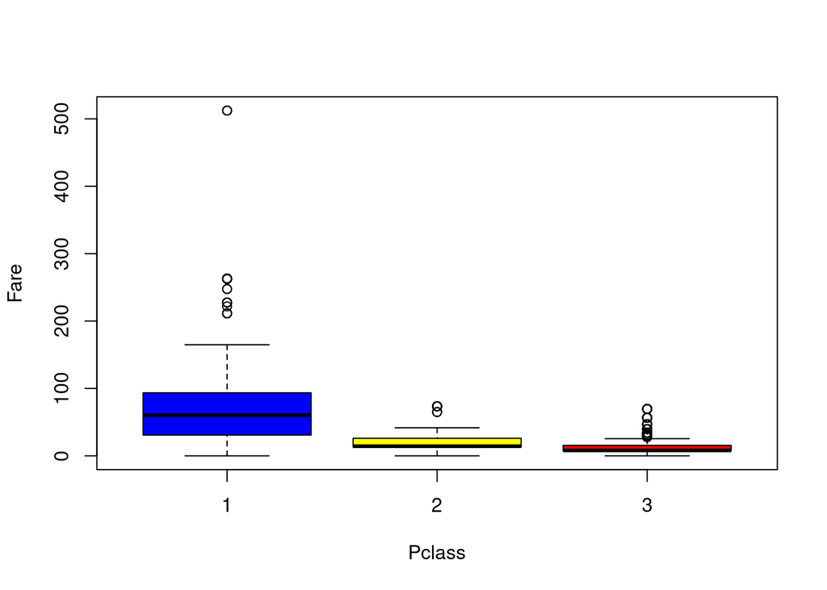

```r
boxplot(data$Fare~data$Pclass,xlab="Pclass",ylab="Fare",
        col=c("blue","yellow","red"))
```

### 3.2.2 Price

Hacemos un análisis similar con la variable Price:

```r
data_out <- as.data.frame(data$Price)
data_out$outlier <- FALSE
for (i in 1:ncol(data_out) - 1){
  columna = data_out[, i]
  if (is.numeric(columna)) {
    media = mean(columna)
    desviacion = sd(columna)
    data_out$outlier = (columna> (media+3*desviacion) | columna<(media-3*desviacion))
  }
}
table(data_out$outlier)
```

```
##
## FALSE  TRUE
##   878    13
```

Con boxplot.stats analizamos los outliers, el valor máximo 221:

```r
boxplot.stats(data$Price)$out
```

```
##  [1]  75.25000 211.50000  61.97920  50.00000  53.10000  52.55420  55.44170
##  [8]  51.47920  76.29170  79.20000  49.50000  67.25000  67.25000  51.86250
## [15]  51.86250  65.75000  65.75000  65.75000  65.75000  70.44583  70.44583
## [22]  70.44583  81.85830  82.43335  82.43335  52.00000  49.50420 221.77920
## [29] 123.76040 123.76040  73.26040  73.26040  51.15417  51.15417  51.15417
## [36]  79.20000  50.49580  61.37920  71.28330  59.40000 131.18750 131.18750
## [43]  49.50420  66.82500  66.82500 170.77640 170.77640 170.77640  83.15830
## [50]  56.88125  56.88125  56.88125  56.88125  54.45000  54.45000  63.35830
## [57]  53.21250  53.21250  61.17500
```

Los valores más altos están presentes en las clases altas:

**Gráfico boxplot Price**

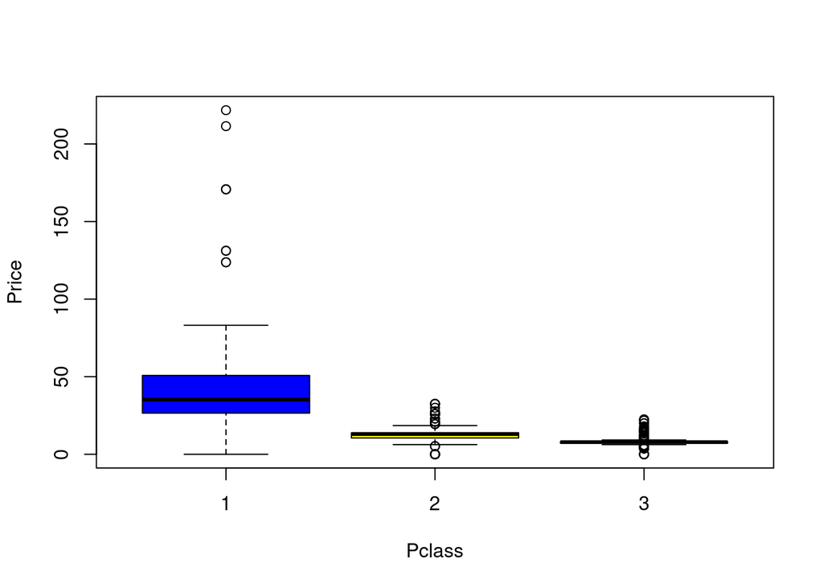

```r
boxplot(data$Price~data$Pclass,xlab="Pclass",ylab="Price",col=c("blue","yellow","red"))
```

Optamos por considerarlos válidos y no realizamos ninguna accion.

### 3.2.3 Age

Hacemos un análisis similar con la variable Age:

```r
data_out <- as.data.frame(data$Age)
data_out$outlier <- FALSE
for (i in 1:ncol(data_out) - 1){
  columna = data_out[, i]
  if (is.numeric(columna)) {
    media = mean(columna)
    desviacion = sd(columna)
    data_out$outlier = (columna> (media+3*desviacion) | columna<(media-3*desviacion))
  }
}
table(data_out$outlier)
```

```
##
## FALSE  TRUE
##   889     2
```

Con boxplot.stats:

```r
boxplot.stats(data$Age)$out
```

```
## [1] 80.0 74.0 70.5 66.0 70.0 71.0 71.0 70.0
```

Podríamos tener 2 valores outliers pero observando los valores devueltos por boxplot.stats no los vamos a considerar significativos.

# 4 Análisis de los datos.

## 4.1 Planificación de los análisis a aplicar.

Nos interesa poder realizar diferentes tipos de análisis en función de diferentes subconjuntos de datos, como puede ser el género, la clase en la que viajan los pasajeros, el puerto en el que han embarcado, grupos por edad, índice de supervivencia de los niños respecto a los adultos, etc.

### 4.1.1 Niños

```r
edad_corte = 8
data$Child[data$Age <= edad_corte] <- 1
data$Child[data$Age > edad_corte] <- 0
data$Child <- as.factor((data$Child))
```

### 4.1.2 Género

Agrupamos por el género, creando una variable para cada uno de los géneros

```r
Mujeres <- data[which(data$Sex == 'female'),]
Hombres <- data[which(data$Sex == 'male'),]
```

### 4.1.3 Lugar de embarque

Agrupamos por el lugar de embarque creando una variable por cada uno de los lugares

```r
EmbarqueC <- data[which(data$Embarked == 'C'),]
EmbarqueQ <- data[which(data$Embarked == 'Q'),]
EmbarqueS <- data[which(data$Embarked == 'S'),]
```

### 4.1.4 Clase

Agrupamos por clase

```r
FirstClass <- data[which(data$Pclass == 1),]
SecondClass <- data[which(data$Pclass == 2),]
ThirdClass <- data[which(data$Pclass == 3),]
```

### 4.1.5 Edades

Vamos a discretizar los valores por grupos de edades, añadiendo una columna al dataset (AgeInterval)

```
##
##   0-12  13-17  18-39  40-54 55-100
##     88     86    532    137     48
```

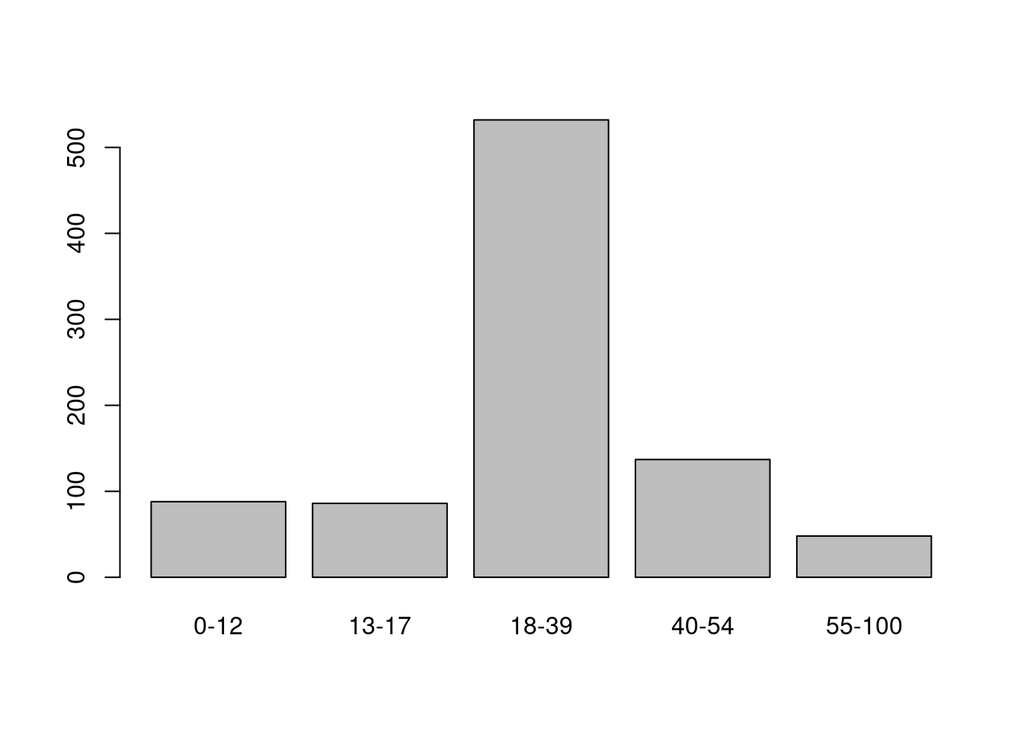

## 4.2 Comprobación de la normalidad y homogeneidad de la varianza.

### 4.2.1 Normalidad

Algunos test estadísticos requieren que las variables que van a ser analizadas sigan una distribución normal, por tanto tenemos que conocer cuáles son las distribuciones de nuestras variables continuas. Estas son las variables **Age** y **Fare**. Además, hemos generado una nueva variable a partir de **Fare**, **Price**, y que, por tanto también es una variable cualitativa continua.

En general, la prueba de *Shapiro-Wilk* se considera una prueba muy potente para contrastar la normalidad de distribuciones. Se asume como hipótesis nula que la población sigue una distribución normal. Si el p-valor obtenido es inferior al nivel de significancia (normalmente α = 0,05) entonces se rechaza la hipótesis nula (y por tanto se concluye que los datos no vienen de una distribución normal). En cambio, si el p-valor es superior al nivel de significancia, entonces no se puede rechazar la hipótesis nula y se asume que los datos siguen una distribución normal. Además, vamos a aplicar otros dos métodos, la prueba de *Anderson-Darling* y la prueba de *Kolmogorov-Smirnov* (conocida también como K-S)

Creamos un data frame para resumir los tests:

```r
tabla.normalidad <- data.frame('variable' = character(),
                               'Test de Normalidad' = character(),
                               'Valor Estadístico' = numeric(),
                               'p-value' = numeric(),
                               stringsAsFactors = FALSE)
str(tabla.normalidad)
```

```
## 'data.frame':    0 obs. of  4 variables:
##  $ variable          : chr
##  $ Test.de.Normalidad: chr
##  $ Valor.Estadístico : num
##  $ p.value           : num
```

Ahora recorremos todas las variables continuas aplicando los tres tests y añadiéndolos al dataframe:

```r
var.continuas <-c("Age", "Fare", "Price")

for (i in 1:length(var.continuas)){
  variable = var.continuas[i]
  #Test Shapiro-wil
  test = shapiro.test(data[,variable])
  tabla.normalidad[nrow(tabla.normalidad)+1,] = c(variable, test$method,
                                                  test$statistic, test$p.value)

  #Test Anderson-Darling
  test = ad.test(data[,variable])
  tabla.normalidad[nrow(tabla.normalidad)+1,] = c(variable, test$method,
                                                  test$statistic, test$p.value)

  #Test Kolmogorov-Smirnov
  test = ks.test(data[,variable], "pnorm", mean=mean(data[,variable]),
                 sd=sd(data[,variable]))
  tabla.normalidad[nrow(tabla.normalidad)+1,] = c(variable, test$method,
                                                  test$statistic, test$p.value)
}

knitr::kable(tabla.normalidad, booktabs = T) %>%
  kable_styling(latex_options = c("striped"))
```

| variable | Test.de.Normalidad | Valor.Estadístico | p.value |
| --- | --- | --- | --- |
| Age | Shapiro-Wilk normality test | 0.981573339303633 | 3.59237516646611e-09 |
| Age | Anderson-Darling normality test | 4.76443331454129 | 8.36895246089196e-12 |
| Age | One-sample Kolmogorov-Smirnov test | 0.062646394633216 | 0.0018355008067592 |
| Fare | Shapiro-Wilk normality test | 0.521891302117355 | 1.08404452322613e-43 |
| Fare | Anderson-Darling normality test | 122.169627214592 | 3.7e-24 |
| Fare | One-sample Kolmogorov-Smirnov test | 0.281848040985975 | 0 |
| Price | Shapiro-Wilk normality test | 0.566484900244852 | 3.00259150054125e-42 |
| Price | Anderson-Darling normality test | 110.325199878766 | 3.7e-24 |
| Price | One-sample Kolmogorov-Smirnov test | 0.26829589819932 | 0 |

En todos los casos el *p-value* ha sido inferior a 0.05 y, por lo tanto, se rechaza la hipótesis nula que implicaba que la variable sigue una distribución normal. Ninguna de las 3 variables sigue una distribución normal.

Revisamos gráficamente la distribución de cada una de las variables usando su histograma, curva de densidad y gráficas Q-Q

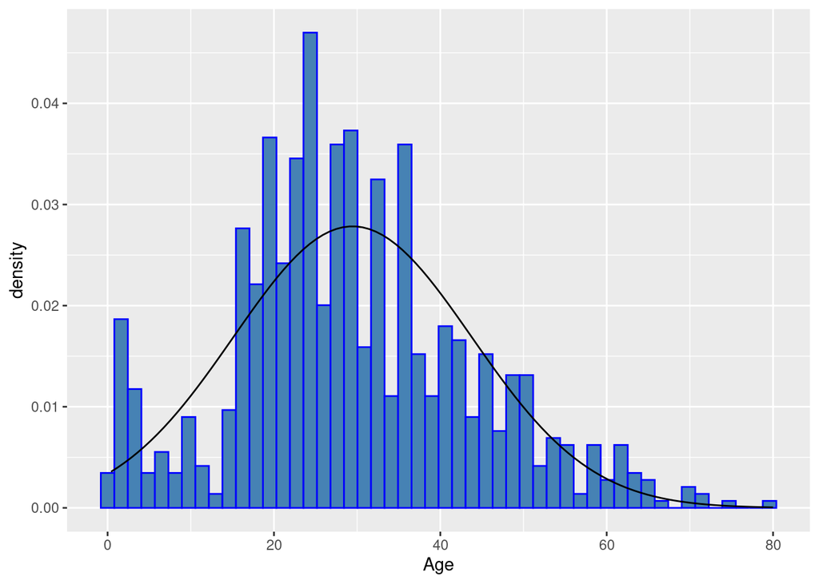

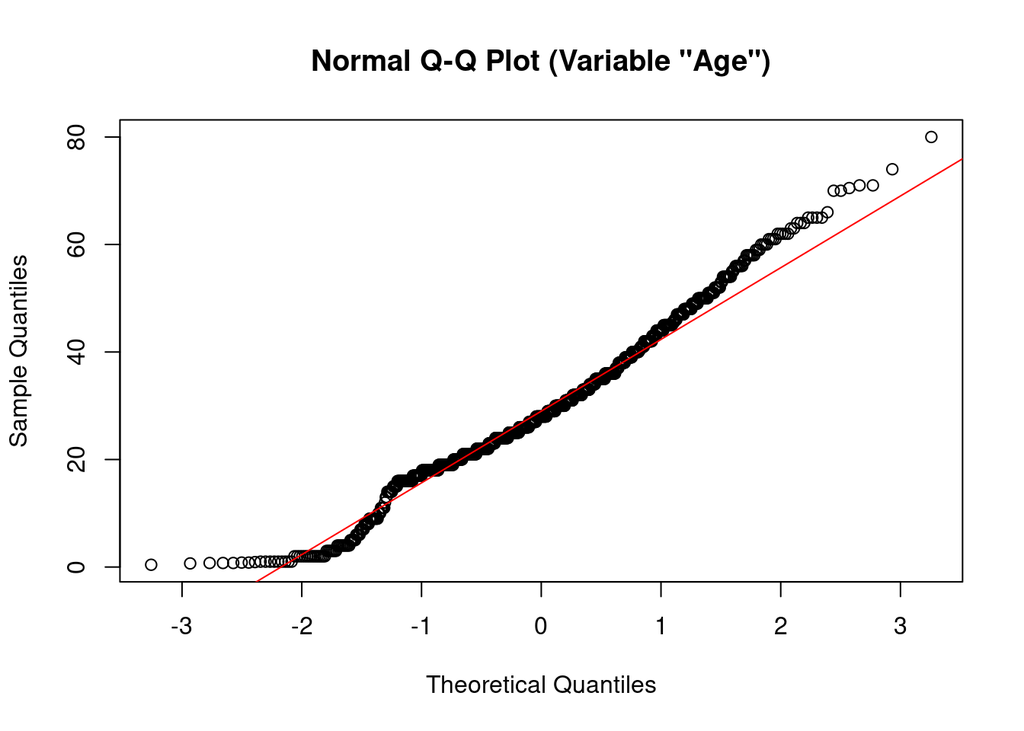

```
## [1] "Age"
```

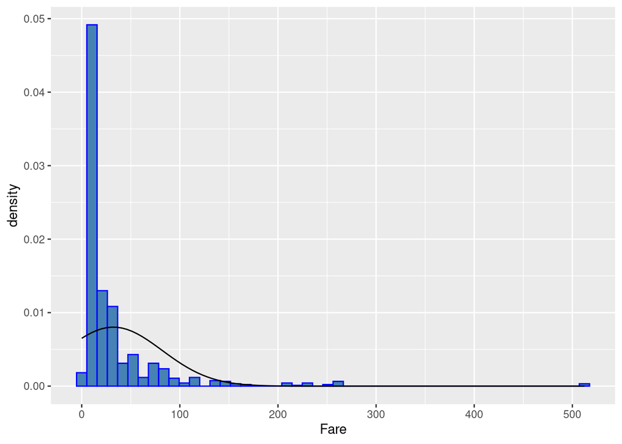

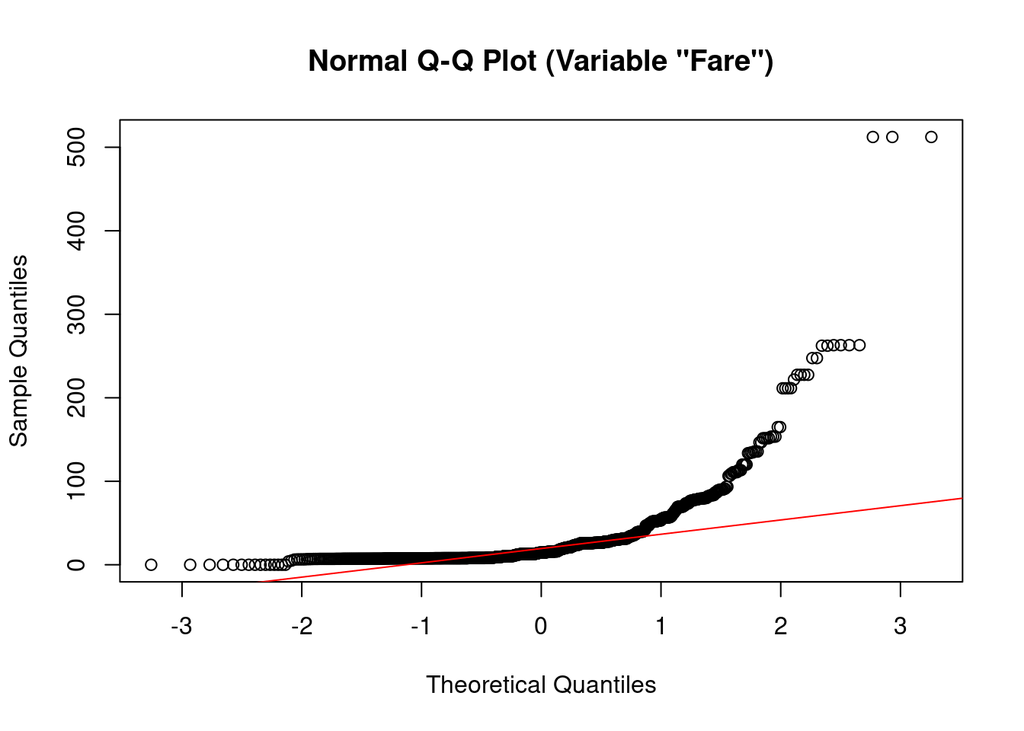

```
## [1] "Fare"
```

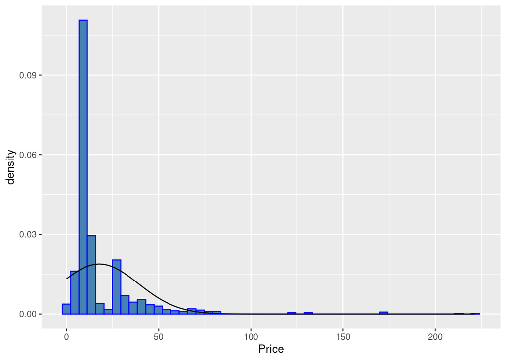

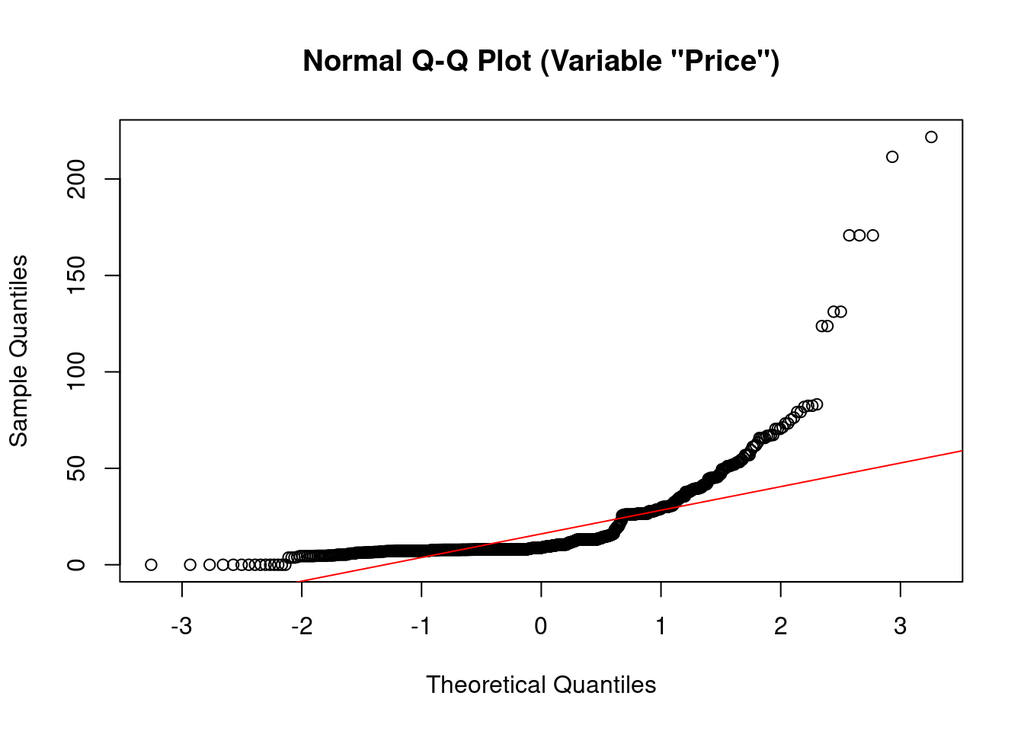

```
## [1] "Price"
```

Observamos que la variable **Age** está próxima a una distribución normal por lo cual podemos utilizar el test de *Levene* para la comprobación de varianzas. Cuando comparamos varianzas lo que estamos comprobando es que las varianzas entre los grupos a comparar son iguales. La hipótesis nula asume la igualdad de varianzas en los diferentes grupos de datos, con lo que si el p-value obtenido es inferior al nivel de significancia (generalmente alpha = 0,05) se rechaza la hipótesis nula y se concluye que hay heterocedasticidad.

#### 4.2.1.1 Age

##### 4.2.1.1.1 Age con Survived

Primero, comprobamos la homogeneidad de varianzas de la edad en los grupos de supervivientes y no supervivientes.

```r
leveneTest(data = data, Age ~ Survived, center = mean)
```

```
## Levene's Test for Homogeneity of Variance (center = mean)
##        Df F value Pr(>F)
## group   1  0.1051 0.7459
##       889
```

En este caso el p-value es superior a 0.05 y por tanto asumimos que hay **homogeneidad de varianzas** entre los grupos

##### 4.2.1.1.2 Age con Embarked

Comprobamos el comportamiento de la varianza cuando se trata de la variable edad **Age** con **Embarked**.

```r
leveneTest(data = data, Age ~ Embarked, center = mean)
```

```
## Levene's Test for Homogeneity of Variance (center = mean)
##        Df F value Pr(>F)
## group   2  1.0532 0.3493
##       888
```

Hay **homogeneidad de varianzas** de **Age** en los grupos que define la variable **Embarked**

##### 4.2.1.1.3 Age con Pclass

Comprobamos el comportamiento de la varianza cuando se trata de la variable edad **Age** con **Pclass**.

```r
leveneTest(data = data, Age ~ Pclass, center = mean)
```

```
## Levene's Test for Homogeneity of Variance (center = mean)
##        Df F value    Pr(>F)
## group   2  7.2088 0.0007841 ***
##       888
## ---
## Signif. codes:  0 '***' 0.001 '**' 0.01 '*' 0.05 '.' 0.1 ' ' 1
```

Hay **heterogeneidad de varianzas** entre las muestras de **Age** cuando se agrupan por **Pclass**

##### 4.2.1.1.4 Age con Sex

Comprobamos el comportamiento de la varianza cuando se trata de la variable edad **Age** con respecto a **Sex**.

```r
leveneTest(data = data, Age ~ Sex, center = mean)
```

```
## Levene's Test for Homogeneity of Variance (center = mean)
##        Df F value Pr(>F)
## group   1  0.1383 0.7101
##       889
```

Hay **homogeneidad de varianzas** para *Age* cuando está agrupado por *Sex*

##### 4.2.1.1.5 Resumen Age

Resumimos en una tabla los resultados de homogeneidad de la varianza de Age con respecto a los distintos atributos:

| Age con respecto a | resultado |
| --- | --- |
| Survived | homogeneidad |
| Embarked | homogeneidad |
| Pclass | heterogeneidad |
| Sex | homogeneidad |

## 4.3 Aplicación de pruebas estadísticas para comparar los grupos de datos.

### 4.3.1 Análisis de relaciones entre variables

Vamos a analizar las relaciones entre variables para aclarar la dependencia entre ellas y como pueden afectar a las posibilidades de supervivencia:

#### 4.3.1.1 Age y Sex

```r
var.test(Mujeres$Age, Hombres$Age)
```

```
##
##  F test to compare two variances
##
## data:  Mujeres$Age and Hombres$Age
## F = 0.93176, num df = 313, denom df = 576, p-value = 0.4845
## alternative hypothesis: true ratio of variances is not equal to 1
## 95 percent confidence interval:
##  0.7689208 1.1355235
## sample estimates:
## ratio of variances
##          0.9317562
```

El resultado nos indica que las varianzas de edad en los grupos de mujeres y hombres son iguales.

Comparamos ahora las medias de los 2 grupos, utilizando *t-Test* indicando que las varianzas de los grupos son iguales. La hipótesis nula será que no hay diferencias significativas entre la media de edades para hombres y mujeres.

```r
t.test(Mujeres$Age, Hombres$Age, var.equal = TRUE)
```

```
##
##  Two Sample t-test
##
## data:  Mujeres$Age and Hombres$Age
## t = -1.7381, df = 889, p-value = 0.08254
## alternative hypothesis: true difference in means is not equal to 0
## 95 percent confidence interval:
##  -3.7147053  0.2254088
## sample estimates:
## mean of x mean of y
##  28.31847  30.06312
```

Queremos comprobar ahora si la media de edad de las mujeres es menor que la de los hombres. Por lo tanto, la hipótesis nula corresponde a que la edad de las mujeres es mayor o igual a la de los hombres:

```r
t.test(Mujeres$Age, Hombres$Age, alternative = "less", var.equal = TRUE)
```

```
##
##  Two Sample t-test
##
## data:  Mujeres$Age and Hombres$Age
## t = -1.7381, df = 889, p-value = 0.04127
## alternative hypothesis: true difference in means is less than 0
## 95 percent confidence interval:
##        -Inf -0.0918529
## sample estimates:
## mean of x mean of y
##  28.31847  30.06312
```

Con un p-value menor de 0.5 rechazamos la hipótesis nula, es decir, podemos afirmar que la media de edad de las mujeres es inferior a la media de edad de los hombres.

#### 4.3.1.2 Survival y Sex

Mostramos gráficamente la relación entre las dos variables:

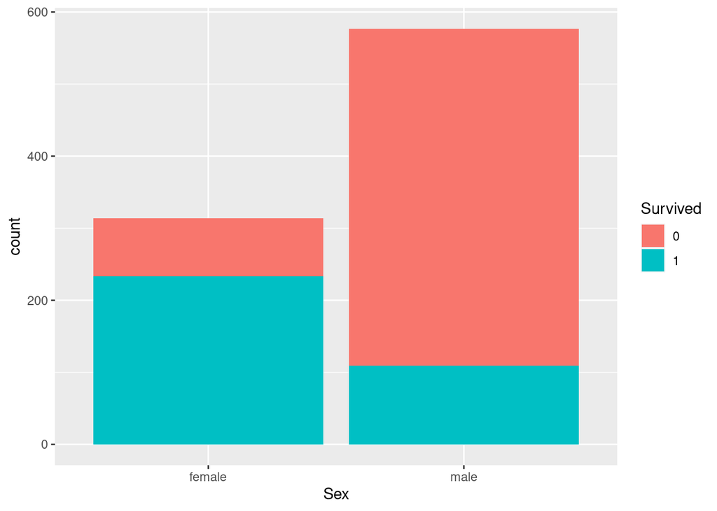

Parece indicar que ser mujer implicaba mas posibilidades de supervivencia que ser hombre. Vamos a confirmar esto realizando algunos contrastes de hipótesis.

Primero, vamos a comprobar la relación entre la supervivencia y el género, analizando si dependiendo de si se era mujer u hombre las posibilidades de supervivencia cambiaban significativamente. Para hacerlo aplicamos el *test exacto de Fisher* que analiza tablas de contingencia. En este caso la hipótesis nula es que la proporción de mujeres que mueren coincide con la proporción de hombre que mueren en el accidente del Titanic.

```r
fisher.test(table(data$Sex, data$Survived))
```

```
##
##  Fisher's Exact Test for Count Data
##
## data:  table(data$Sex, data$Survived)
## p-value < 2.2e-16
## alternative hypothesis: true odds ratio is not equal to 1
## 95 percent confidence interval:
##  0.0575310 0.1138011
## sample estimates:
## odds ratio
## 0.08128333
```

Con un p-valor < 0.05 rechazamos la hipótesis nula, es decir: **hay diferente proporción de supervivencia entre hombres y mujeres.**

Una vez confirmado que el género si que importaba, vamos a ver quien tiene más probabilidades de supervivencia, si las mujeres o los hombres. La hipótesis nula sería que la proporción de mujeres que mueren es mayor que la de los hombres.

```r
fisher.test(table(data$Sex, data$Survived), alternative = 'less')
```

```
##
##  Fisher's Exact Test for Count Data
##
## data:  table(data$Sex, data$Survived)
## p-value < 2.2e-16
## alternative hypothesis: true odds ratio is less than 1
## 95 percent confidence interval:
##  0.0000000 0.1081391
## sample estimates:
## odds ratio
## 0.08128333
```

El valor de p-value inferior a 0.05) con lo que se cumple la hipótesis alternativa: **la proporción de mujeres que mueren es inferior a la de los hombres**.

#### 4.3.1.3 Survival y Pclass

Mostramos gráficamente la relación entre las dos variables:

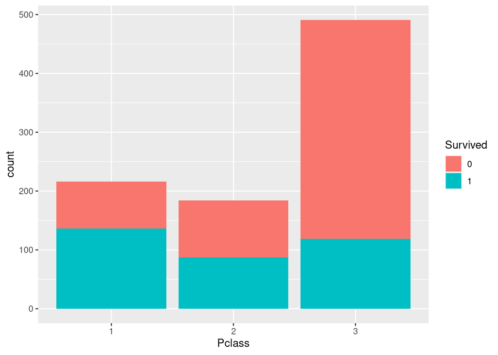

El porcentaje de supervivencia por clases disminuye desde la primera hasta la tercera clase, las clases con mas superviencia eran las mejores. Para comprobarlo utilizamos el test *Chi-Cuadrado* (son variables categóricas). Aquí la hipótesis nula nos dice que las variables son independientes.

```r
test_chisq <- chisq.test(data$Pclass, data$Survived)
test_chisq
```

```
##
##  Pearson's Chi-squared test
##
## data:  data$Pclass and data$Survived
## X-squared = 102.89, df = 2, p-value < 2.2e-16
```

El valor de p-value es inferior a 0.05, es decir, rechazamos la hipótesis nula, y por tanto afirmamos que las variables no son independientes. Esto quiere decir que **el grado de supervivencia era distinto dependiendo de la clase en la que estuvieses**.

#### 4.3.1.4 Survived y Embarked

Mostramos gráficamente la relación entre las dos variables:

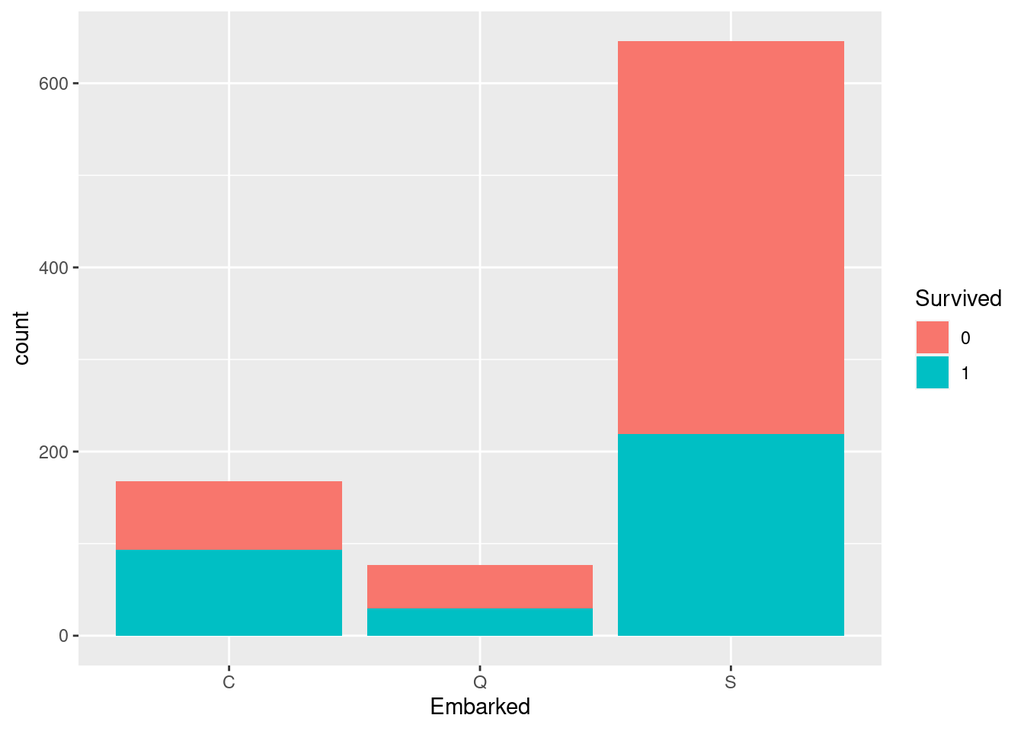

Parece indicar que los embarcados en Southampton tenían menos posibilidades de sobrevivir (tal vez por el número de clase al que accedían). Utilizamos *Chi-Squared* para analizar la relación entre las variables **Embarked** y **Survived**.

```r
test_chisq <- chisq.test(data$Embarked, data$Survived)
test_chisq
```

```
##
##  Pearson's Chi-squared test
##
## data:  data$Embarked and data$Survived
## X-squared = 25.964, df = 2, p-value = 2.301e-06
```

Se rechaza la hipótesis nula, por lo tanto **las variables son dependientes**.

#### 4.3.1.5 Survived y Child

Mostramos gráficamente la relación entre las dos variables, siendo **Child** una variable que corresponde a los niños de edad igual o inferior a 8 años:

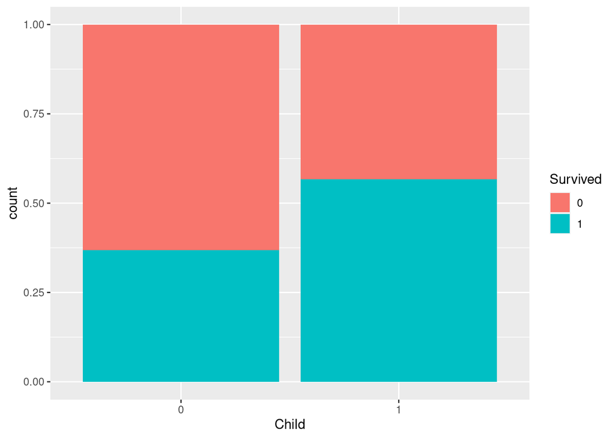

Parece que hay más esperanza de supervivencia en ese caso. Aplicamos el *test de Fisher* para comprobar si tienen las mismas probabilidades de supervivencia que el resto de pasajeros.

```r
fisher.test(table(data$Child, data$Survived))
```

```
##
##  Fisher's Exact Test for Count Data
##
## data:  table(data$Child, data$Survived)
## p-value = 0.001657
## alternative hypothesis: true odds ratio is not equal to 1
## 95 percent confidence interval:
##  1.315090 3.847717
## sample estimates:
## odds ratio
##   2.239271
```

Se rechaza la hipótesis nula, es decir que **las proporciones no coinciden**. Analizamos ahora si las probabilidades de supervivencia son mayores o menores. Para ello analizamos si la proporción de no-niños que no sobreviven es menor a la proporción de niños que no sobreviven:

```r
fisher.test(table(data$Child, data$Survived), alternative = 'greater')
```

```
##
##  Fisher's Exact Test for Count Data
##
## data:  table(data$Child, data$Survived)
## p-value = 0.001204
## alternative hypothesis: true odds ratio is greater than 1
## 95 percent confidence interval:
##  1.424655      Inf
## sample estimates:
## odds ratio
##   2.239271
```

Se rechaza la hipótesis nula, y se acepta la alternativa, es decir que la **probabilidad de muerte de los no-niños es mayor que la de los niños**.

#### 4.3.1.6 Survived y Age

Comprobamos ahora si la media de edad de las personas que murieron es similar con la media de edad que sobrevivieron, aplicando el test *t-Test*.

```r
t.test(data$Age[which(data$Survived==0)], data$Age[which(data$Survived == 1)])
```

```
##
##  Welch Two Sample t-test
##
## data:  data$Age[which(data$Survived == 0)] and data$Age[which(data$Survived == 1)]
## t = 1.6097, df = 705.26, p-value = 0.1079
## alternative hypothesis: true difference in means is not equal to 0
## 95 percent confidence interval:
##  -0.3514748  3.5512763
## sample estimates:
## mean of x mean of y
##  30.06239  28.46249
```

```r
wilcox.test(x = data$Age[which(data$Survived==0)],
            y = data$Age[which(data$Survived==1)],
            paired =FALSE
            )
```

```
##
##  Wilcoxon rank sum test with continuity correction
##
## data:  data$Age[which(data$Survived == 0)] and data$Age[which(data$Survived == 1)]
## W = 97760, p-value = 0.2987
## alternative hypothesis: true location shift is not equal to 0
```

La prueba no-paramétrica nos devuelve un p-value por encima de 0.05 y por tanto no rechazamos la hipótesis nula, con lo que podemos decir que **la media de edad es similar entre los muertos y los supervivientes del Titanic**.

Gráficamente podemos comprobarlo mediante un Boxplot

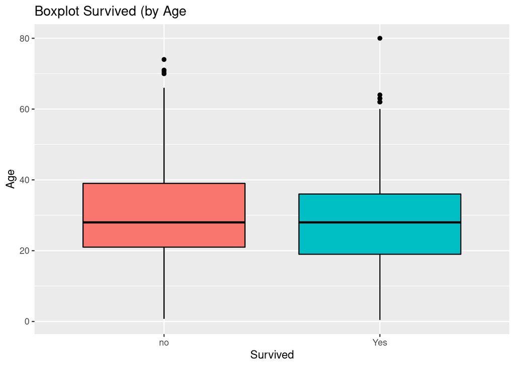

Se puede apreciar que las distribuciones son muy parecidas.

### 4.3.2 Modelos

Vamos a aplicar diversos modelos predictivos con respecto a la variable **Survived**. Vamos a utilizar como variables explicativas las variables que traía por defecto el conjunto de datos original, menos las que hemos eliminado durante el proceso de transformación y limpieza de datos.

Creamos un conjunto de entrenamiento y un conjunto de test. Es decir,vamos a crear una partición, un 75% de datos para el entrenamiento, y el 25% restante para validar los modelos.

```r
index_train <- createDataPartition(data$Survived, p=.75, list = FALSE)
data_train <-data[index_train,]
data_test <- data[-index_train, ]
```

Creamos una función que nos imprima correctamente las matrices de confusión a partir de un CrossTable.

```r
# Función necesaria para imprimir la matriz de confusión a partir de un CrossTable
plot_matriz_confusion <- function(par_crosstable) {
  #Obtenemos la matriz de confusion en porcentaje
  datplotconfusion <- as.data.frame(par_crosstable[2]$prop.row)
  colnames(datplotconfusion) <- c('Observacion','Prediccion','Valor')
  datplotconfusion$Valor <- datplotconfusion$Valor*100
  #Ordenamos los factores de las clases
  datplotconfusion <- datplotconfusion %>% arrange(Observacion)
  clasesord <- sort(as.character(levels(datplotconfusion$Observacion)),decreasing = FALSE)
  datplotconfusion$Observacion <- factor(datplotconfusion$Observacion, levels = clasesord)
  #Ordenar las clases descendente (para el plot)
  clasesinv<-rev(as.character(unique(datplotconfusion$Observacion)))

  plot1 <- ggplot() +
    geom_tile(aes(x=Observacion, y=Prediccion,fill=Valor),
              data=datplotconfusion, color="black",size=0.1) +
    labs(x="Observación real (%)",y="Predicción (%)") +
    scale_y_discrete(limits=clasesinv)

  plot1 = plot1 +
    geom_text(aes(x=Observacion, y=Prediccion, label=sprintf("%.2f", Valor)),
              data=datplotconfusion, size=3, colour="black") +
    scale_fill_gradient(low="gray",high="red")

  #Obtenemos la matriz de confusion en numero de muestras
  datplotconfusion <- as.data.frame(par_crosstable[1]$t)
  colnames(datplotconfusion) <- c('Observacion','Prediccion','Valor')
  #Ordenamos los factores de las clases
  datplotconfusion <- datplotconfusion %>% arrange(Observacion)
  clasesord <- sort(as.character(levels(datplotconfusion$Observacion)),decreasing = FALSE)
  datplotconfusion$Observacion <- factor(datplotconfusion$Observacion, levels = clasesord)
  #Ordenar las clases descendente (para el plot)
  clasesinv<-rev(as.character(unique(datplotconfusion$Observacion)))
  plot2 <- ggplot() +
    geom_tile(aes(x=Observacion, y=Prediccion,fill=Valor),
              data=datplotconfusion, color="black",size=0.1) +
    labs(x="Observación real (nº)",y="Predicción (nº)") +
    scale_y_discrete(limits=clasesinv)

  plot2 = plot2 +
    geom_text(aes(x=Observacion, y=Prediccion, label=sprintf("%d", Valor)),
              data=datplotconfusion, size=3, colour="black") +
    scale_fill_gradient(low="gray",high="red")
  return(grid.arrange(plot1, plot2, ncol=2))
}
```

Creamos un dataframe en donde iremos guardando los distintos valores de precisión y errores de clasificación.

```r
tabla.modelos <- data.frame('Modelo' = character(),
                               'Precisión' = numeric(),
                               'Errores' = numeric(),
                               stringsAsFactors = FALSE)

str(tabla.modelos)
```

```
## 'data.frame':    0 obs. of  3 variables:
##  $ Modelo   : chr
##  $ Precisión: num
##  $ Errores  : num
```

#### 4.3.2.1 Modelo de regresión logística

Un modelo de regresión logística es un tipo de análisis de regresión que se utiliza para predecir el resultado de una variable categórica, en función de las variables independientes. Nuestra variable objetivo es **Survived**, que toma los valores de 0 o 1 (1 cuando el pasajero sobrevivió al accidente y 0 en caso contrario).

##### 4.3.2.1.1 Primer modelo glm

Creamos un primer modelo glm1 con las variables “original”: **Pclass**, **SibSp**, **Parch**, **Sex**, **Age**, **Fare** y **Embarked**

```r
modelo_glm1 <- glm(formula=Survived~ Pclass+SibSp+Parch+Sex+Age+Fare+Embarked, data = data_train, family = binomial(link = "logit"))
summary(modelo_glm1)
```

```
##
## Call:
## glm(formula = Survived ~ Pclass + SibSp + Parch + Sex + Age +
##     Fare + Embarked, family = binomial(link = "logit"), data = data_train)
##
## Deviance Residuals:
##     Min       1Q   Median       3Q      Max
## -2.4459  -0.6849  -0.4251   0.6291   2.3410
##
## Coefficients:
##              Estimate Std. Error z value Pr(>|z|)
## (Intercept)  3.612678   0.519877   6.949 3.68e-12 ***
## Pclass2     -0.739694   0.334114  -2.214 0.026836 *
## Pclass3     -2.040088   0.334118  -6.106 1.02e-09 ***
## SibSp       -0.236448   0.121225  -1.950 0.051119 .
## Parch       -0.125800   0.133279  -0.944 0.345229
## Sexmale     -2.566677   0.227643 -11.275  < 2e-16 ***
## Age         -0.026784   0.007825  -3.423 0.000619 ***
## Fare         0.002248   0.002626   0.856 0.391945
## EmbarkedQ   -0.249211   0.433601  -0.575 0.565462
## EmbarkedS   -0.472015   0.269107  -1.754 0.079430 .
## ---
## Signif. codes:  0 '***' 0.001 '**' 0.01 '*' 0.05 '.' 0.1 ' ' 1
##
## (Dispersion parameter for binomial family taken to be 1)
##
##     Null deviance: 891.19  on 668  degrees of freedom
## Residual deviance: 613.33  on 659  degrees of freedom
## AIC: 633.33
##
## Number of Fisher Scoring iterations: 5
```

Se puede observar que tanto las variables **Fare** como **Parch** no aportan nada a la hora de predecir la variable **Survived**. En el caso de la variable Sex, al tener 2 valores se ha creado la variable **Sexmale**, es decir la parte correspondiente a hombres, mientras que la parte de mujeres forma parte del Intercept del modelo. Concretamente vemos que **Sexmale** es una variable significativa, pero con valor negativo (junto con **Pclass3**). Eso significa que esas variables contribuyen negativamente de cara a la supervivencia.

Ahora usamos el conjunto de datos de test para validar nuestro modelo. (Para este primer modelo mostramos el código como ejemplo)

```r
predict_glm1 <- predict(object=modelo_glm1, newdata=data_test, type = "response")
r1 <- pROC::roc(response=data_test$Survived, predictor = predict_glm1)
threshold_r1 <- pROC::coords(r1, "best", ret = "threshold", transpose="FALSE")
predict_glm1 <- if_else(predict_glm1 < threshold_r1[1,1], 0, 1)
mat.confusion_glm1 <- table(data_test$Survived, predict_glm1)
mat.confusion_glm1
```

```
##    predict_glm1
##       0   1
##   0 124  13
##   1  19  66
```

```r
pct.correcto_glm1 <- 100 * sum(diag(mat.confusion_glm1)) / sum(mat.confusion_glm1)
print(sprintf("El %% de registros correctamente clasificados es: %.4f %%",
              pct.correcto_glm1))
```

```
## [1] "El % de registros correctamente clasificados es: 85.5856 %"
```

```r
csstab_glm1 <- CrossTable(data_test$Survived, predict_glm1,
                          prop.chisq  = FALSE, prop.c = FALSE, prop.r =FALSE,
                          dnn = c('Reality', 'Prediction'))
```

```
##
##
##    Cell Contents
## |-------------------------|
## |                       N |
## |         N / Table Total |
## |-------------------------|
##
##
## Total Observations in Table:  222
##
##
##              | Prediction
##      Reality |         0 |         1 | Row Total |
## -------------|-----------|-----------|-----------|
##            0 |       124 |        13 |       137 |
##              |     0.559 |     0.059 |           |
## -------------|-----------|-----------|-----------|
##            1 |        19 |        66 |        85 |
##              |     0.086 |     0.297 |           |
## -------------|-----------|-----------|-----------|
## Column Total |       143 |        79 |       222 |
## -------------|-----------|-----------|-----------|
##
##
```

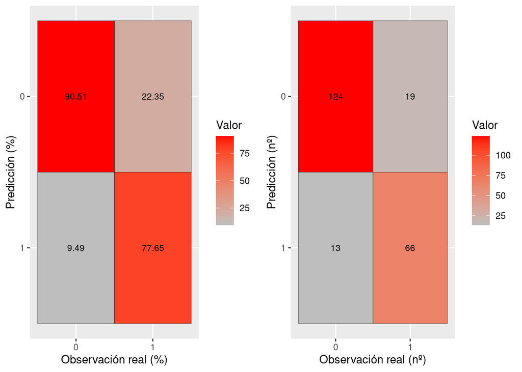

```r
plot_matriz_confusion(csstab_glm1)
```

```r
tabla.modelos[nrow(tabla.modelos)+1,] = c("glm1", pct.correcto_glm1, sum(mat.confusion_glm1)-sum(diag(mat.confusion_glm1)))
```

##### 4.3.2.1.2 Segundo modelo glm

Construimos un segundo modelo (glm2), similar al anterior pero esta vez partiendo de los resultados del modelo anterior, le vamos a quitar aquellas variables que vimos que no eran significativas para el modelo de predicción. Por lo tanto, tendremos un modelo2 cuyas variables a utilizar serán **Pclass**, **SibSp**, **Sex** y **Age**.

```r
modelo_glm2 <- glm(formula=Survived~ Pclass+SibSp+Sex+Age, data = data_train, family = binomial(link = "logit"))
summary(modelo_glm2)
```

```
##
## Call:
## glm(formula = Survived ~ Pclass + SibSp + Sex + Age, family = binomial(link = "logit"),
##     data = data_train)
##
## Deviance Residuals:
##     Min       1Q   Median       3Q      Max
## -2.5245  -0.6737  -0.4310   0.6257   2.3881
##
## Coefficients:
##              Estimate Std. Error z value Pr(>|z|)
## (Intercept)  3.471193   0.423769   8.191 2.59e-16 ***
## Pclass2     -1.017832   0.292607  -3.478 0.000504 ***
## Pclass3     -2.276724   0.272902  -8.343  < 2e-16 ***
## SibSp       -0.272582   0.113608  -2.399 0.016425 *
## Sexmale     -2.546428   0.218050 -11.678  < 2e-16 ***
## Age         -0.027118   0.007803  -3.476 0.000510 ***
## ---
## Signif. codes:  0 '***' 0.001 '**' 0.01 '*' 0.05 '.' 0.1 ' ' 1
##
## (Dispersion parameter for binomial family taken to be 1)
##
##     Null deviance: 891.19  on 668  degrees of freedom
## Residual deviance: 618.65  on 663  degrees of freedom
## AIC: 630.65
##
## Number of Fisher Scoring iterations: 5
```

```
##    predict_glm2
##       0   1
##   0 122  15
##   1  18  67
```

```
## [1] "El % de registros correctamente clasificados es: 85.1351 %"
```

```
##
##
##    Cell Contents
## |-------------------------|
## |                       N |
## |         N / Table Total |
## |-------------------------|
##
##
## Total Observations in Table:  222
##
##
##              | Prediction
##      Reality |         0 |         1 | Row Total |
## -------------|-----------|-----------|-----------|
##            0 |       122 |        15 |       137 |
##              |     0.550 |     0.068 |           |
## -------------|-----------|-----------|-----------|
##            1 |        18 |        67 |        85 |
##              |     0.081 |     0.302 |           |
## -------------|-----------|-----------|-----------|
## Column Total |       140 |        82 |       222 |
## -------------|-----------|-----------|-----------|
##
##
```

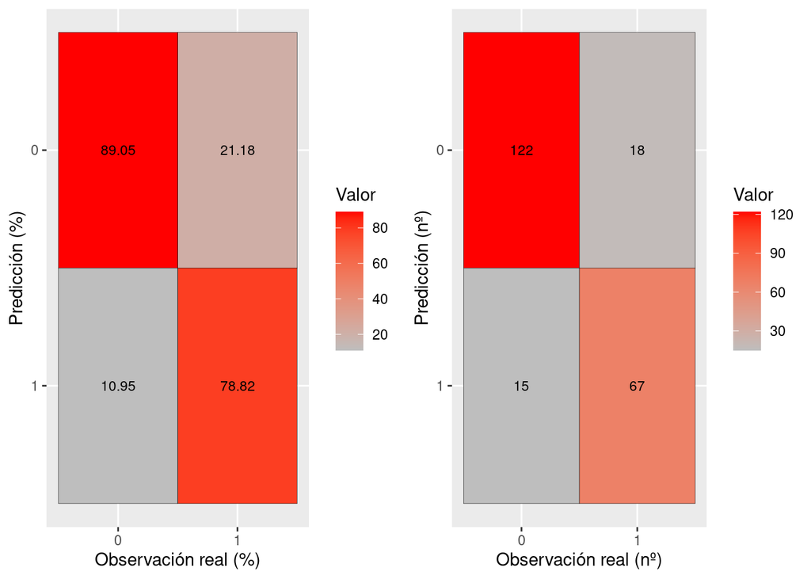

##### 4.3.2.1.3 Tercer modelo glm

Construimos un tercer modelo (glm3), pero esta vez vamos a intentar utilizar alguna de las variables que hemos construido para ayudar a predecir la supervivencia. Para este caso vamos a utilizar las variables nuevas **Child** y también **FamilySize**. Además, vamos a utilizar tres variables originales: **Pclass**, **Sex** y **Age**.

```r
modelo_glm3 <- glm(formula=Survived~ Sex+Pclass+Age+Child+FamilySize,, data = data_train, family = binomial(link = "logit"))
summary(modelo_glm3)
```

```
##
## Call:
## glm(formula = Survived ~ Sex + Pclass + Age + Child + FamilySize,
##     family = binomial(link = "logit"), data = data_train)
##
## Deviance Residuals:
##     Min       1Q   Median       3Q      Max
## -2.7131  -0.7012  -0.4318   0.5935   2.3558
##
## Coefficients:
##              Estimate Std. Error z value Pr(>|z|)
## (Intercept)  3.295556   0.478909   6.881 5.93e-12 ***
## Sexmale     -2.685475   0.229168 -11.718  < 2e-16 ***
## Pclass2     -0.964359   0.293376  -3.287  0.00101 **
## Pclass3     -2.185323   0.274059  -7.974 1.54e-15 ***
## Age         -0.013287   0.008945  -1.485  0.13743
## Child1       1.315074   0.450494   2.919  0.00351 **
## FamilySize  -0.232295   0.075458  -3.078  0.00208 **
## ---
## Signif. codes:  0 '***' 0.001 '**' 0.01 '*' 0.05 '.' 0.1 ' ' 1
##
## (Dispersion parameter for binomial family taken to be 1)
##
##     Null deviance: 891.19  on 668  degrees of freedom
## Residual deviance: 609.73  on 662  degrees of freedom
## AIC: 623.73
##
## Number of Fisher Scoring iterations: 5
```

```
##    predict_glm3
##       0   1
##   0 116  21
##   1  13  72
```

```
## [1] "El % de registros correctamente clasificados es: 84.6847 %"
```

```
##
##
##    Cell Contents
## |-------------------------|
## |                       N |
## |         N / Table Total |
## |-------------------------|
##
##
## Total Observations in Table:  222
##
##
##              | Prediction
##      Reality |         0 |         1 | Row Total |
## -------------|-----------|-----------|-----------|
##            0 |       116 |        21 |       137 |
##              |     0.523 |     0.095 |           |
## -------------|-----------|-----------|-----------|
##            1 |        13 |        72 |        85 |
##              |     0.059 |     0.324 |           |
## -------------|-----------|-----------|-----------|
## Column Total |       129 |        93 |       222 |
## -------------|-----------|-----------|-----------|
##
##
```

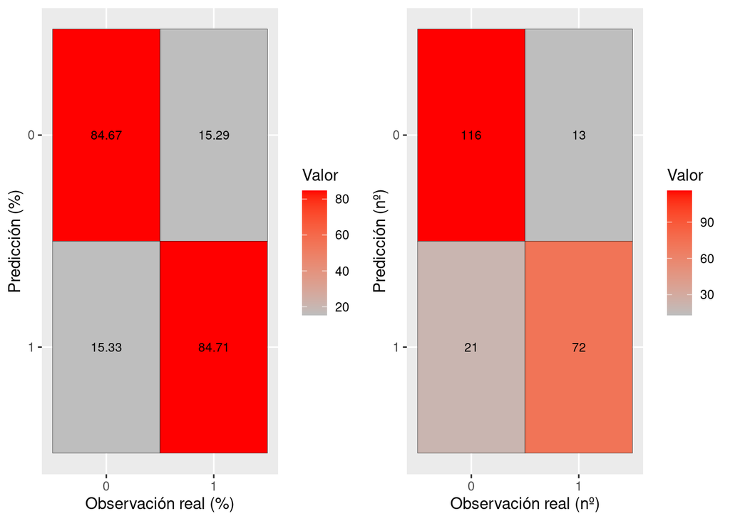

##### 4.3.2.1.4 Resumen modelos regresion

Los diferentes modelos se han comportado de la siguiente forma:

```r
knitr::kable(tabla.modelos, booktabs = T) %>%
  kable_styling(latex_options = c("striped"))
```

| Modelo | Precisión | Errores |
| --- | --- | --- |
| glm1 | 85.5855855855856 | 32 |
| glm2 | 85.1351351351351 | 33 |
| glm3 | 84.6846846846847 | 34 |

#### 4.3.2.2 Árboles de decisión

Los árboles de decisión son modelos muy sencillos de construir. Utilizaremos los “Recursive Partitioning and Regression Tree” que proporciona la libreria `rpart`

##### 4.3.2.2.1 Primer árbol de decisión

Creamos un primer árbol con los parámetros básicos

```r
tctrl <- caret::trainControl(method = "repeatedcv",
                             number=10, repeats = 3)
model_tree1 <- caret::train(Survived~Sex+FamilySize+Child+Age+Pclass,
                            data=data_train,
                            method="rpart",
                            trControl = tctrl)
summary(model_tree1)
```

[output not shown]

[output cut: 484 more lines]

```
##   Surrogate splits:
##       Pclass2    < 0.5  to the left,  agree=0.715, adj=0.363, (0 split)
##       Age        < 26.5 to the left,  agree=0.658, adj=0.235, (0 split)
##       FamilySize < 4.5  to the right, agree=0.627, adj=0.167, (0 split)
##       Child1     < 0.5  to the right, agree=0.575, adj=0.049, (0 split)
##
## Node number 6: 102 observations
##   predicted class=0  expected loss=0.4509804  P(node) =0.1524664
##     class counts:    56    46
##    probabilities: 0.549 0.451
##
## Node number 7: 126 observations
##   predicted class=1  expected loss=0.03968254  P(node) =0.1883408
##     class counts:     5   121
##    probabilities: 0.040 0.960
```

Dibujamos el árbol

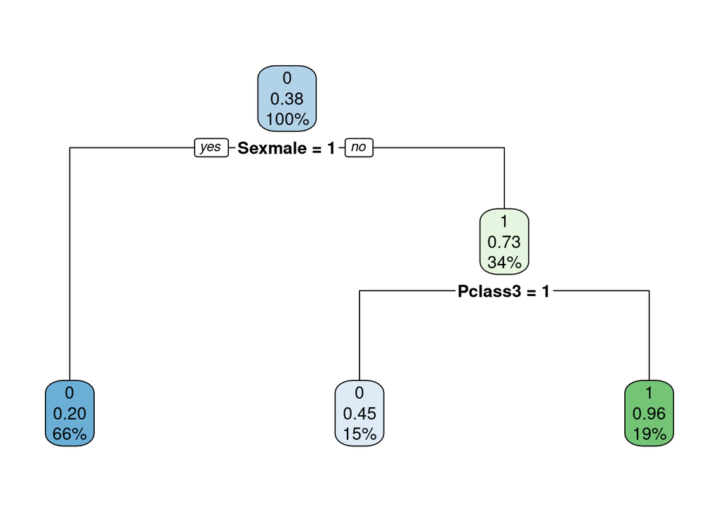

```r
rpart.plot(model_tree1$finalModel)
```

Realizamos la predicción con el modelo construido con rpart y el dataset test

```
##    predict_tree1
##       0   1
##   0 133   4
##   1  45  40
```

```
## [1] "El % de registros correctamente clasificados es: 77.9279 %"
```

```
##
##
##    Cell Contents
## |-------------------------|
## |                       N |
## |         N / Table Total |
## |-------------------------|
##
##
## Total Observations in Table:  222
##
##
##              | Prediction
##      Reality |         0 |         1 | Row Total |
## -------------|-----------|-----------|-----------|
##            0 |       133 |         4 |       137 |
##              |     0.599 |     0.018 |           |
## -------------|-----------|-----------|-----------|
##            1 |        45 |        40 |        85 |
##              |     0.203 |     0.180 |           |
## -------------|-----------|-----------|-----------|
## Column Total |       178 |        44 |       222 |
## -------------|-----------|-----------|-----------|
##
##
```

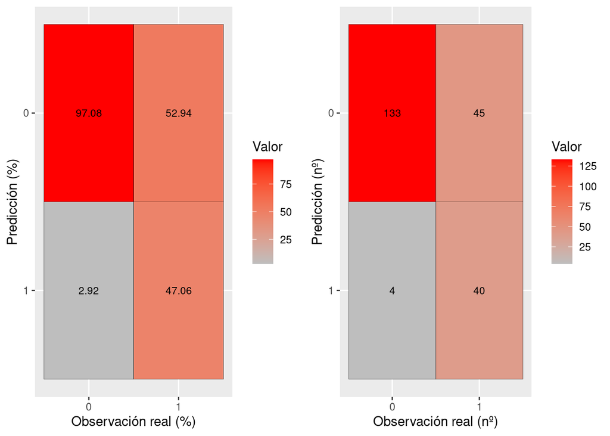

##### 4.3.2.2.2 Segundo árbol de decisión

Manteniendo las mismas variables predictivas, pero cambiando la profundidad máxima del árbol (maxdepth) se pueden mejorar los resultados obtenidos:

```r
tctrl <- caret::trainControl(method = "repeatedcv",
                             number=10, repeats = 3)
tgrid <- data.frame(maxdepth = seq(2,10,1))

model_tree2<- train(Survived ~ Sex+FamilySize+Child+Age+Pclass,
                    data=data_train,
                    trControl=tctrl,
                    tuneGrid=tgrid,
                    method="rpart2")
```

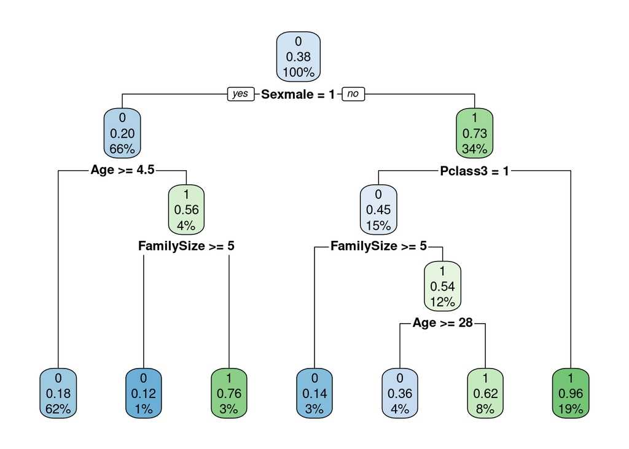

[output not shown]

[output cut: 556 more lines]

```
##   left son=26 (25 obs) right son=27 (55 obs)
##   Primary splits:
##       Age        < 27.5 to the right, improve=2.29136400, (0 missing)
##       Child1     < 0.5  to the left,  improve=1.56756400, (0 missing)
##       FamilySize < 2.5  to the right, improve=0.01067393, (0 missing)
##
## Node number 26: 25 observations
##   predicted class=0  expected loss=0.36  P(node) =0.03736921
##     class counts:    16     9
##    probabilities: 0.640 0.360
##
## Node number 27: 55 observations
##   predicted class=1  expected loss=0.3818182  P(node) =0.08221226
##     class counts:    21    34
##    probabilities: 0.382 0.618
```

Realizamos la predicción con el modelo construido con rpart y el dataset test:

```
##    predict_tree2
##       0   1
##   0 123  14
##   1  28  57
```

```
## [1] "El % de registros correctamente clasificados es: 81.0811 %"
```

```
## [1] "El mejor parámetro para el árbol de clasificación ha sido: maxdepth=6"
```

**Matriz de confusión**

```r
csstab_tree2 <- CrossTable(data_test$Survived, predict_tree2,
                           prop.chisq  = FALSE, prop.c = FALSE, prop.r =FALSE,
                           dnn = c('Reality', 'Prediction'))
```

```
##
##
##    Cell Contents
## |-------------------------|
## |                       N |
## |         N / Table Total |
## |-------------------------|
##
##
## Total Observations in Table:  222
##
##
##              | Prediction
##      Reality |         0 |         1 | Row Total |
## -------------|-----------|-----------|-----------|
##            0 |       123 |        14 |       137 |
##              |     0.554 |     0.063 |           |
## -------------|-----------|-----------|-----------|
##            1 |        28 |        57 |        85 |
##              |     0.126 |     0.257 |           |
## -------------|-----------|-----------|-----------|
## Column Total |       151 |        71 |       222 |
## -------------|-----------|-----------|-----------|
##
##
```

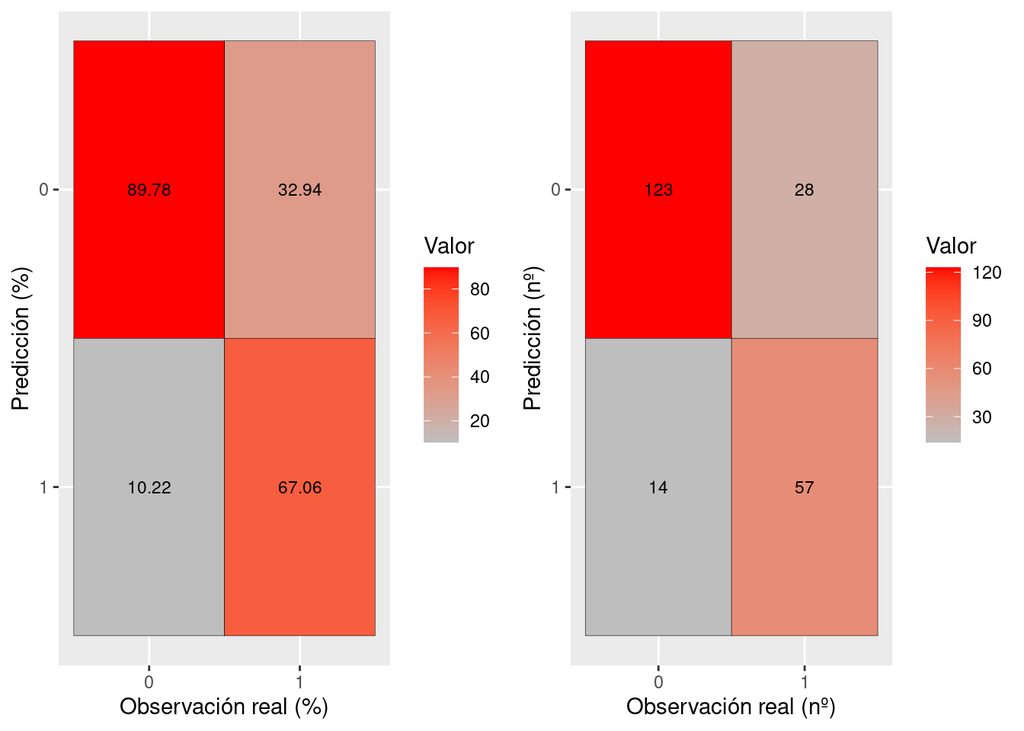

```r
plot_matriz_confusion(csstab_tree2)
```

**Importancia de las variables**

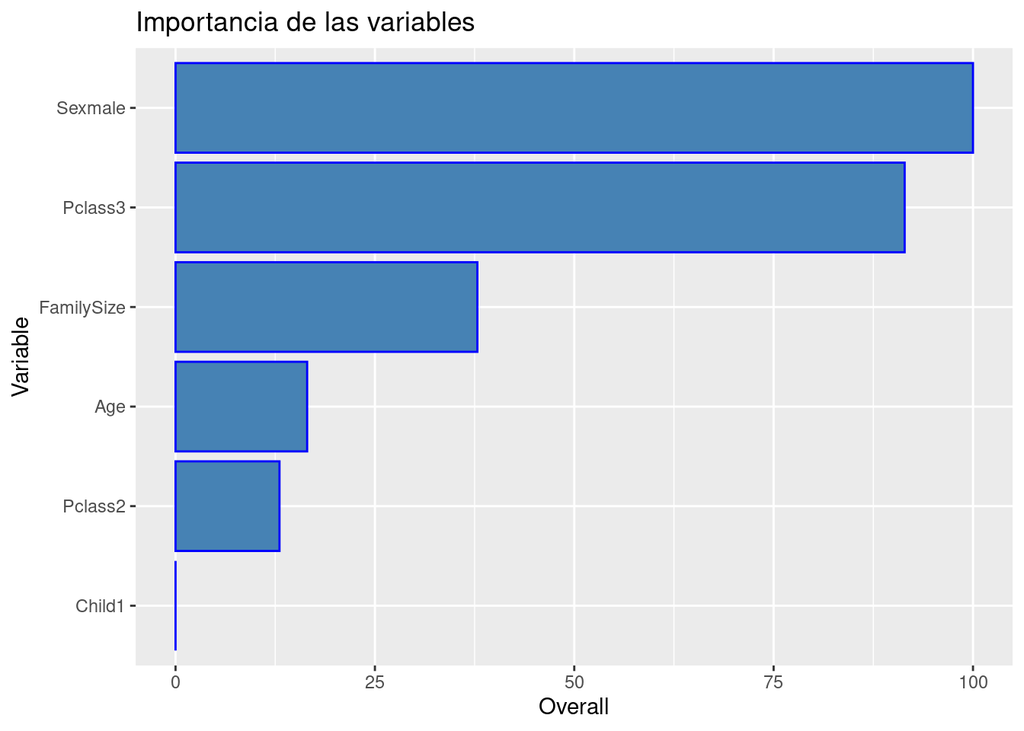

```r
datosVarImp <- varImp(model_tree2)$importance %>%
  as.data.frame() %>%
  rownames_to_column() %>%
  arrange(Overall)
datosVarImp$Variable <- reorder(datosVarImp$rowname, datosVarImp$Overall)
ggplot(datosVarImp)+
  geom_col(aes(x = Variable, y = Overall), fill="steelblue", color="blue")+
  coord_flip() + ggtitle("Importancia de las variables")
```